[figure not shown]

Machine Learning und Deep Learning bei Zeitreihenprognosen - Vergleich verschiedener Algorithmen am Beispiel von Kupferpreisen am Weltmarkt

Projektarbeit im Modul "Machine Learning mit Python"  
des Studiengangs M.Sc. Data Science - Advanced Business Analytics  
der Hochschule der Medien Stuttgart  
https://github.com/andreashrb/Python_for_ML_Project  
Ersteller: Sebastian Wölk, Andreas Herb  
Mai 2022

# Einleitung

Unabhängig davon, ob es nun um die Entwicklung der Finanzmärkte, der Rohstoffpreise oder des Stromverbrauchs geht - in beiden Fällen ist die Zeit ein wichtiger Faktor im Rahmen der Analyse. Auch im betrieblichen Umfeld hat die Analyse von Daten mit zeitlichem Bezug eine große Bedeutung. So ist es wenig verwunderlich, dass sich Unternehmen in ihren ersten Gehversuchen im KI-Umfeld häufig zunächst mit Zeitreihenanalysen und dem anschließenden Forecasting der Zeitreihendaten beschäftigen.

Der Begriff Zeitreihe stammt aus der Mathematik und beschreibt den zeitlichen Verlauf von Beobachtungen bzw. Messgrößen. Die Vorhersage der zukünftigen Werte einer Messgröße basierend auf der vorhandenen Zeitreihe d.h. mittels historischer Daten, wird als Zeitreihenanalyse bzw. Zeitreihenprognose (Time Series Forecasting) bezeichnet.

Sei es zur Cashflow- oder Umsatzprognose, der Nachfrage- oder Beschaffungsplanung oder im Personalbereich zur besseren Steuerung von Personaleinsatz: Es finden sich entlang der gesamten Wertschöpfungskette überall dort Anwendungsfälle, wo es historische Daten über die Zeit gibt. Das Zeitintervall (jährlich, monatlich, täglich) kann dabei flexibel gewählt und Use-Case-spezifisch angepasst werden.

## Business Understanding / Ziel des Projektes

Rohstoffpreise dienen seit Langem als Frühindikator für wirtschaftliche Entwicklungen, z.B. weltweite Inflationen. Dies liegt an ihrer schnellen und zeitnahen Verfügbarkeit sowie den hochfrequenten Veränderungen.

In den letzten zwei Jahren waren diese Schwankungen besonders ausgeprägt. Infolge von Lockdownmaßnahmen, Naturkatastrophen und Vorfällen, wie dem Stau im Suezkanal, sind Rohstoffpreise weltweit explosionsartig innerhalb kürzester Zeit gestiegen. Dies stellt Industrieunternehmen und deren Einkäufer sowie Supply-Chain-Controller nahezu täglich vor große Herausforderungen und verlangt immer häufiger und kurzfristiger weitreichende Entscheidungen:

- Steigen die Preise weiter oder sind sinkende Preise zu erwarten?
- Soll daher bereits heute Nachschub geordert werden oder kann die Bestellung noch einige Tage aufgeschoben werden?

Mit einem entsprechenden Forecasting kann nicht immer eine punktgenaue Vorhersage getroffen werden, jedoch erleichtert es in vielen Fällen die Beantwortung der oben gestellten Fragestellungen und kann als zusätzliche Entscheidungshilfe herangezogen werden.

In der vorliegenden Projektarbeit soll sich am Beispiel von Kupferpreisen der London Metal Exchange (Rohstoffbörse in London) dieser Problemstellung angenommen werden. Dazu kommen verschiedene Algorithmen zur Zeitreihenprognose (englisch "Time series prediction / forecasting") zum Einsatz, die auf ihre Eignung geprüft, beispielhaft implementiert sowie bewertet werden sollen. Es werden sowohl Modelle des klassischen Machine-Learnings als auch aus dem Bereich des aktuell viel diskutierten Deep Learnings mit neuronalen Netzen herangezogen.

## Vorgehensweise

[figure not shown]

Die Vorgehensweise der vorliegenden Arbeit orientiert sich grundsätzlich am im Data-Science-Umfeld üblichen Modell des CRISP-DMs. CRISP-DM steht für **C**Ross-**I**ndustry **S**tandard **P**rocess for **D**ata **M**ining. Dieses branchenübergreifende Prozess-Modell wurde ab 1996 im Rahmen eines EU-Förderprojekts entwickelt.

Da jedoch der Schwerpunkt dieses Moduls auf dem Machine-Learning-Part liegt, wurden die weiteren Bestandteile - im Wesentlichen das "Data Understanding / Data Exploration" sowie die "Data Preparation / Feature Engineering" - ausgelagert und in separaten Jupyter-Notebooks in einem Github-Folder abgelegt.

Diese sind wie folgt zu finden:

- **Data Scraping / Loading**: [Scraping & Loading](http://htmlpreview.github.io/?https://github.com/andreashrb/Python_for_ML_Project/blob/main/interim_results/1%20-%20Scrapping_Loading_Copper_Economic_Data.html)
- **Data Joining**: [Data Joining](http://htmlpreview.github.io/?https://github.com/andreashrb/Python_for_ML_Project/blob/main/interim_results/2%20-%20Joining_Copper-EconomicData.html)
- **Data Understanding / Data Exploration**: [Data Exploration](http://htmlpreview.github.io/?https://github.com/andreashrb/Python_for_ML_Project/blob/main/interim_results/3%20-%20Data%20Exploration_CopperPrice_CopperStock.html)
- **Data Preparation / Feature Engineering**: [Data Prep & Feature Engineering](http://htmlpreview.github.io/?https://github.com/andreashrb/Python_for_ML_Project/blob/main/interim_results/4%20-%20DataPreparation_FeatureEngineering.html)

Das gesamte Projekt ist daneben in einem Github-Repository abgespeichert und öffentlich zugänglich: https://github.com/andreashrb/Python_for_ML_Project

# Laden benötigter Pakete

```python
import pandas as pd
from sklearn.ensemble import RandomForestRegressor
from sklearn.ensemble import GradientBoostingRegressor
from sklearn.model_selection import GridSearchCV
import matplotlib.pyplot as plt
from matplotlib.pyplot import figure
from pylab import rcParams
from sklearn.inspection import permutation_importance
import numpy as np
import tensorflow as tf
from tensorflow import keras
from sklearn.metrics import mean_squared_error, r2_score
from sklearn.metrics import mean_absolute_error,  median_absolute_error
from tensorflow.keras.wrappers.scikit_learn import KerasRegressor
from sklearn.preprocessing import MinMaxScaler
import markdown

RANDOM_SEED = 42
rcParams['figure.figsize'] = 22, 10
np.random.seed(RANDOM_SEED)
tf.random.set_seed(RANDOM_SEED)
```

```python
# Aufbau einer Funktion zur Berechnung mehrerer Regressionsmetriken
# Innerhalb der Funktionen werden wiederum Funktionen aus dem sklearn-Package (Modul: Metrics) verwendet.

def determineRegressionMetrics(y_test,y_pred,title=""):
    mse = mean_squared_error(y_test, y_pred)
    mad = mean_absolute_error(y_test, y_pred)
    rmsle=np.sqrt(mean_squared_error(np.log(y_test+1),np.log(y_pred+1)))# +1 for avoiding log(0)
    r2=r2_score(y_test, y_pred)
    med=median_absolute_error(y_test, y_pred)
    print(title)
    print("Mean absolute error =", round(mad, 2))
    print("Mean squared error =", round(mse, 2))
    print("Median absolute error =", round(med, 2))
    print("R2 score =", round(r2, 2))
    print("Root Mean Squared Logarithmic Error =",rmsle)
```

# Einlesen der preparierten Daten

```python
df = pd.read_csv('https://raw.githubusercontent.com/andreashrb/Python_for_ML_Project/main/data/input_output_data.csv', sep=',', encoding='utf-8', index_col=[0,1], decimal=".", thousands=",", parse_dates=['date'])
```

```python
df.head()
```

| id | date | lme_copper_cash__cwt_coefficients__coeff_10__w_5__widths_(2, 5, 10, 20) | lme_copper_cash__cwt_coefficients__coeff_9__w_5__widths_(2, 5, 10, 20) | lme_copper_cash__cwt_coefficients__coeff_10__w_10__widths_(2, 5, 10, 20) | lme_copper_cash__cwt_coefficients__coeff_9__w_2__widths_(2, 5, 10, 20) | lme_copper_cash__cwt_coefficients__coeff_10__w_20__widths_(2, 5, 10, 20) | lme_copper_cash__cwt_coefficients__coeff_8__w_5__widths_(2, 5, 10, 20) | lme_copper_cash__cwt_coefficients__coeff_9__w_10__widths_(2, 5, 10, 20) | lme_copper_cash__cwt_coefficients__coeff_9__w_20__widths_(2, 5, 10, 20) | lme_copper_cash__cwt_coefficients__coeff_8__w_10__widths_(2, 5, 10, 20) | lme_copper_cash__cwt_coefficients__coeff_7__w_5__widths_(2, 5, 10, 20) | ... | lme_copper_stock__spkt_welch_density__coeff_2 | lme_copper_cash__permutation_entropy__dimension_6__tau_1 | lme_copper_stock__energy_ratio_by_chunks__num_segments_10__segment_focus_8 | lme_copper_cash__energy_ratio_by_chunks__num_segments_10__segment_focus_8 | lme_copper_stock__autocorrelation__lag_7 | lme_copper_cash__change_quantiles__f_agg_"var"__isabs_True__qh_0.8__ql_0.0 | lme_copper_stock__cwt_coefficients__coeff_4__w_5__widths_(2, 5, 10, 20) | lme_copper_stock__approximate_entropy__m_2__r_0.7 | lme_copper_stock__agg_linear_trend__attr_"rvalue"__chunk_len_10__f_agg_"mean" | lme_copper_cash |
| --- | --- | --- | --- | --- | --- | --- | --- | --- | --- | --- | --- | --- | --- | --- | --- | --- | --- | --- | --- | --- | --- | --- |
| 1 | 2012-01-08 | 8602.117939 | 10935.500183 | 9020.109055 | 5011.405561 | 7080.385602 | 12767.469234 | 10704.946656 | 8287.179311 | 12320.592967 | 14057.267868 | ... | 3.599714e+08 | 1.791759 | 0.0 | 0.0 | -0.873027 | 0.000000 | 600683.121935 | 0.000000 | -1.0 | 7574.75 |
|  | 2012-01-15 | 8602.117939 | 10935.500183 | 9020.109055 | 5011.405561 | 7080.385602 | 12767.469234 | 10704.946656 | 8287.179311 | 12320.592967 | 14057.267868 | ... | 3.599714e+08 | 1.791759 | 0.0 | 0.0 | -0.873027 | 0.000000 | 600683.121935 | 0.000000 | -1.0 | 7749.00 |
|  | 2012-01-22 | 8602.117939 | 10935.500183 | 9020.109055 | 5011.405561 | 7080.385602 | 12767.469234 | 10704.946656 | 8287.179311 | 12320.592967 | 14057.267868 | ... | 3.599714e+08 | 1.791759 | 0.0 | 0.0 | -0.873027 | 0.000000 | 600683.121935 | 0.000000 | -1.0 | 8188.60 |
|  | 2012-01-29 | 8602.117939 | 10935.500183 | 9020.109055 | 5011.405561 | 7080.385602 | 12767.469234 | 10704.946656 | 8287.179311 | 12320.592967 | 14057.267868 | ... | 4.510042e+05 | 1.791759 | 0.0 | 0.0 | -0.873027 | 17602.655625 | 600683.121935 | 0.405465 | -1.0 | 8408.20 |
|  | 2012-02-05 | 8602.117939 | 10935.500183 | 9020.109055 | 5011.405561 | 7080.385602 | 12767.469234 | 10704.946656 | 8287.179311 | 12320.592967 | 14057.267868 | ... | 1.361986e+07 | 1.791759 | 0.0 | 0.0 | -0.873027 | 17602.655625 | 357920.129377 | 0.287682 | -1.0 | 8379.00 |

5 rows × 232 columns

```python
df.shape
```

```
(470, 232)
```

# Preprocessing and Modelling

Im Rahmen dieses Notebooks sollen die zugrundeliegenden Daten (s.o.) für verschiedene Modelle vorbereitet werden, um anschließend eine Prognose für den Kupferpreis (Spalte im DataFrame: lme_copper_cash) mithilfe dieser Modelle abzuleiten.

Verwendet werden sollen sowohl klassische Machine Learning-Methoden, als auch Methoden des Deep Learnings.

## Decision Trees (Random Forest / XGBoost)

Immer wieder sehr erfolgreich, und zu den klassischen Machine Learning-Methoden zählend, werden Decision Tree's diskutiert. Diese Decision Tree's können durchaus auch für Zeitreihenprobleme genutzt werden. Anders als z.B. ein ARIMA-Modell, welches für die Lösung von Zeitreihenproblemen optimiert ist, sind Decision Trees originär nicht speziell für die Lösung von Zeitreihenproblemen entwickelt worden. Decision Tree's sind allerdings in der Lage Klassifikations- als auch Regressionsprobleme zu lösen. Somit eignen sie sich ebenfalls zur Lösung von Zeitreihenproblemen, insbesondere multivariaten Zeitreihenproblemen.

In der gesamten Data Science Community sind insbesondere der Random Forest und der Gradient Boosting Tree (auch: XGBoost) immer wieder stark performende ML-Modelle und schneiden in diversen ML-Wettbewerben, z.B. auch auf Kaggle, sehr gut ab, weshalb auch in Rahmen dieses Notebooks der Random Forest / XG Boost stellvertretend für die Kategorie der Decision Trees unter den vielzähligen Machine Learning Modellen angewendet werden sollen.

Die notwendigen Data Preprocessing-Schritte auf den bereits vorbereiteten Daten mit bereits erfolgter Feature Extraction und Feature Selection zur Anwendung eines Decision Tree (speziell: Random Forest / XG Boost) orientieren sich an folgender Quelle: https://www.tmwr.org/pre-proc-table.html.

Demnach ist für Random Forest, als auch Boosting Tree-Modelle, lediglich die Imputation als zwingende Preprocessing-Maßnahme anzuwenden. Diese wurde bereits im Rahmen der Feature Selection im Teil "Data Preparation" vorgenommen.

### Train-Test-Split

```python
# Länge des DataFrames
print(len(df))
```

```
470
```

```python
# Einfacher Train-Test-Split

train_size = int(len(df)*0.8)
test_size = len(df) - train_size
df_train, df_test = df.iloc[0:train_size], df.iloc[train_size:len(df)]
```

```python
print(df_train.shape)
print(df_test.shape)
```

```
(376, 232)
(94, 232)
```

**Trainingsdaten:** 376 Datensätze mit 232 Features

**Testdaten:** 94 Datensätze mit 232 Features

Unter den 232 Features befindet sich allerdings ebenso noch die Zielvariable "lme_copper_cash". Diese muss im Folgenden noch separiert werden, um zu folgender Struktur zu kommen:

- x_train
- y_train
- x_test
- y_test

```python
# Separieren von Input- und Output-Daten (x,y)
x_train = df_train.loc[:, df.columns != 'lme_copper_cash']
y_train = df_train['lme_copper_cash']

x_test = df_test.loc[:, df.columns != 'lme_copper_cash']
y_test = df_test['lme_copper_cash']
```

```python
print(x_train.shape)
print(y_train.shape)
```

```
(376, 231)
(376,)
```

```python
print(x_test.shape)
print(y_test.shape)
```

```
(94, 231)
(94,)
```

### Random Forest Regressor

```python
# Erstellen des Modells ohne Festlegung bestimmter Hyperparameter (Verwendung der Default-Werte)
rf_regr = RandomForestRegressor(random_state=1234, verbose=True)
```

```python
# Trainieren des Modells
rf_regr.fit(x_train, y_train)
```

```
[Parallel(n_jobs=1)]: Using backend SequentialBackend with 1 concurrent workers.
[Parallel(n_jobs=1)]: Done 100 out of 100 | elapsed:    3.1s finished
```

```
RandomForestRegressor(random_state=1234, verbose=True)
```

```python
ypred = rf_regr.predict(x_test)
```

```
[Parallel(n_jobs=1)]: Using backend SequentialBackend with 1 concurrent workers.
[Parallel(n_jobs=1)]: Done 100 out of 100 | elapsed:    0.0s finished
```

```python
# Kalkulieren des R2
rf_regr.score(x_test, y_test)
```

```
[Parallel(n_jobs=1)]: Using backend SequentialBackend with 1 concurrent workers.
[Parallel(n_jobs=1)]: Done 100 out of 100 | elapsed:    0.0s finished
```

```
0.9250814821717438
```

```python
# Berechnung verschiedener Performancemetriken für das trainierte und auf den Testdaten evaluierte Modell
determineRegressionMetrics(y_test, y_pred=ypred)
```

```
Mean absolute error = 119.18
Mean squared error = 31284.99
Median absolute error = 67.03
R2 score = 0.93
Root Mean Squared Logarithmic Error = 0.029163166862390556
```

#### Hyperparameteroptimierung mit GridSearch

```python
# Definition der Parameter und ihrer Wertebereiche für das Hyperparametertuning im Rahmen des Modelltrainings als Dict

rf_param = {'n_estimators':[200, 250, 300, 350],
            'max_depth':[15,20,25,30]}
```

```python
# Erstellen des GridSearch-Objekts
rf_regr_gridsearch = GridSearchCV(rf_regr, rf_param, scoring='neg_mean_absolute_error')
```

```python
# Trainieren des Modells unter Verwendung der GridSearch-Methode mit 5-fold-cv
rf_regr_gridsearch.fit(x_train, y_train)
```

[output not shown]

[output cut: 267 more lines]

[output not shown]

```
GridSearchCV(estimator=RandomForestRegressor(random_state=1234, verbose=True),
             param_grid={'max_depth': [15, 20, 25, 30],
                         'n_estimators': [200, 250, 300, 350]},
             scoring='neg_mean_absolute_error')
```

```python
rf_regr_gridsearch.cv_results_
```

```
{'mean_fit_time': array([3.127073  , 3.49333177, 4.18078232, 4.93662825, 2.83639545,
        3.59272285, 4.48008161, 5.14181652, 2.87280378, 3.74365053,
        4.46492739, 5.29535093, 3.03757343, 3.5739028 , 4.24844632,
        4.99321256]),
 'std_fit_time': array([0.61438421, 0.08925773, 0.0229379 , 0.10676983, 0.05130385,
        0.07819597, 0.11557681, 0.08245883, 0.06452925, 0.1791324 ,
        0.10134429, 0.22117084, 0.19216363, 0.09178238, 0.08073356,
        0.11724015]),
 'mean_score_time': array([0.02021985, 0.02081089, 0.0249228 , 0.02727122, 0.01693139,
        0.02040491, 0.02331038, 0.02580624, 0.02179022, 0.02512298,
        0.02761097, 0.02700195, 0.01740217, 0.02315097, 0.02380581,
        0.02634883]),
 'std_score_time': array([0.00690753, 0.00146845, 0.00186098, 0.00116517, 0.00064799,
        0.00135716, 0.00107139, 0.00040021, 0.00740107, 0.00951016,
        0.00773692, 0.00141897, 0.00135522, 0.00583945, 0.00074863,
        0.0004299 ]),
 'param_max_depth': masked_array(data=[15, 15, 15, 15, 20, 20, 20, 20, 25, 25, 25, 25, 30, 30,
                    30, 30],
              mask=[False, False, False, False, False, False, False, False,
                    False, False, False, False, False, False, False, False],
        fill_value='?',
             dtype=object),
 'param_n_estimators': masked_array(data=[200, 250, 300, 350, 200, 250, 300, 350, 200, 250, 300,
                    350, 200, 250, 300, 350],
              mask=[False, False, False, False, False, False, False, False,
                    False, False, False, False, False, False, False, False],
        fill_value='?',
             dtype=object),
 'params': [{'max_depth': 15, 'n_estimators': 200},
  {'max_depth': 15, 'n_estimators': 250},
  {'max_depth': 15, 'n_estimators': 300},
  {'max_depth': 15, 'n_estimators': 350},
  {'max_depth': 20, 'n_estimators': 200},
  {'max_depth': 20, 'n_estimators': 250},
  {'max_depth': 20, 'n_estimators': 300},
  {'max_depth': 20, 'n_estimators': 350},
  {'max_depth': 25, 'n_estimators': 200},
  {'max_depth': 25, 'n_estimators': 250},
  {'max_depth': 25, 'n_estimators': 300},
  {'max_depth': 25, 'n_estimators': 350},
```

[output cut: 18 more lines]

```
        -187.18698833, -187.75244311, -186.16145926, -190.44187302,
        -187.18698833, -187.75244311, -186.16145926, -190.44187302]),
 'split4_test_score': array([-92.52481222, -93.88633467, -92.91793704, -93.47269873,
        -92.58576722, -93.93509867, -92.95070704, -93.5007873 ,
        -92.58576722, -93.93509867, -92.95070704, -93.5007873 ,
        -92.58576722, -93.93509867, -92.95070704, -93.5007873 ]),
 'mean_test_score': array([-281.26972349, -281.29854383, -279.55355918, -280.02839669,
        -281.25368737, -281.28571494, -279.53993808, -279.97792635,
        -281.25368737, -281.28571494, -279.53993808, -279.97792635,
        -281.25368737, -281.28571494, -279.53993808, -279.97792635]),
 'std_test_score': array([280.26256575, 277.93286706, 277.25473656, 276.37541238,
        280.20083342, 277.88349072, 277.2119984 , 276.26303693,
        280.20083342, 277.88349072, 277.2119984 , 276.26303693,
        280.20083342, 277.88349072, 277.2119984 , 276.26303693]),
 'rank_test_score': array([12, 16,  4,  8,  9, 13,  1,  5,  9, 13,  1,  5,  9, 13,  1,  5])}
```

```python
# Ausgabe der besten Parameterkombination
rf_regr_gridsearch.best_params_
```

```
{'max_depth': 20, 'n_estimators': 300}
```

```python
# Ausgabe der Performance bei der besten Parameterkombination aus dem Modelltraining bei bester Hyperparameterkombination
rf_regr_gridsearch.best_score_
```

```
-279.53993808089757
```

```python
# Vorhersage auf den Testdaten (mit besten Hyperparametern)
rf_grid_pred = rf_regr_gridsearch.predict(x_test)
```

```
[Parallel(n_jobs=1)]: Using backend SequentialBackend with 1 concurrent workers.
[Parallel(n_jobs=1)]: Done 300 out of 300 | elapsed:    0.0s finished
```

```python
# Bewerten der Prognosegenauigkeit auf den Testdaten

rf_regr_gridsearch.score(x_test, y_test)
```

```
[Parallel(n_jobs=1)]: Using backend SequentialBackend with 1 concurrent workers.
[Parallel(n_jobs=1)]: Done 300 out of 300 | elapsed:    0.0s finished
```

```
-113.99523640661965
```

```python
# Berechnung verschiedener Performancemetriken für das trainierte und auf den Testdaten evaluierte Modell
perf_rf = determineRegressionMetrics(y_test, y_pred=rf_grid_pred)
perf_rf
```

```
Mean absolute error = 114.0
Mean squared error = 29520.16
Median absolute error = 59.96
R2 score = 0.93
Root Mean Squared Logarithmic Error = 0.027823558137097814
```

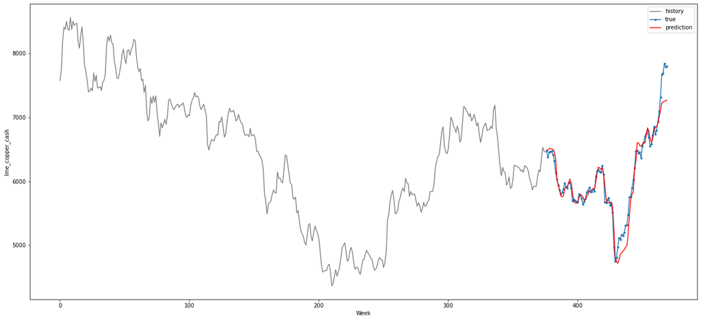

```python
# Visualisieren der gesamten Zeitreihe inkl. Prediction des XGB
plt.plot(np.arange(0, len(y_train)), y_train, '0.5', label="history")
plt.plot(np.arange(len(y_train), len(y_train) + len(y_test)), y_test, marker='.', label="true")
plt.plot(np.arange(len(y_train), len(y_train) + len(y_test)), rf_grid_pred, 'r', label="prediction")
plt.ylabel('lme_copper_cash')
plt.xlabel('Week')
plt.legend()
plt.show();
```

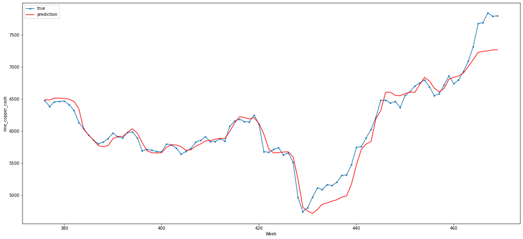

```python
# Visualisierung der Performance (Prognosegüte) auf den Testdaten
plt.plot(np.arange(len(y_train), len(y_train) + len(y_test)), y_test, marker='.', label="true")
plt.plot(np.arange(len(y_train), len(y_train) + len(y_test)), rf_grid_pred, 'r', label="prediction")
plt.ylabel('lme_copper_cash')
plt.xlabel('Week')
plt.legend()
plt.show();
```

Der Random Forest hat augenscheinlich eine sehr gute Anpassungsfähigkeit an die zugrundeliegenden Testdaten und performt sehr gut. Schwierigkeiten hat der Random Forest bei der Prognose des Kupferpreises in den letzten Wochen der Testdaten, in denen der Kupferpreis sehr stark und sehr schnell ansteigt. Hier nimmt die Prognosegüte in den letzten Wochen der Testdaten stark ab. Ebenfalls problematisch scheint der plötzliche Anstieg des wöchentlichen Kupferpreises ab ca. Woche 430 zu sein. Auch hier schafft es der Random Forest nicht, mit den zur Verfügung stehenden Features, sich direkt und kurzfristig an die Entwicklung anzupassen.

#### Feature Importance beim Random Forest

```python
# Berechnung der Feature Importance des Random Forest Regressors auf den Testdaten
vip_rf = permutation_importance(rf_regr_gridsearch, x_test, y_test, n_repeats=5,random_state=1234)
```

[output not shown]

[output cut: 2257 more lines]

[output not shown]

```python
# Ausgabe der durchschnittlichen Feature Importance (je Feature) über alle 5 Durchläufe
vip_rf.importances_mean
```

[output not shown]

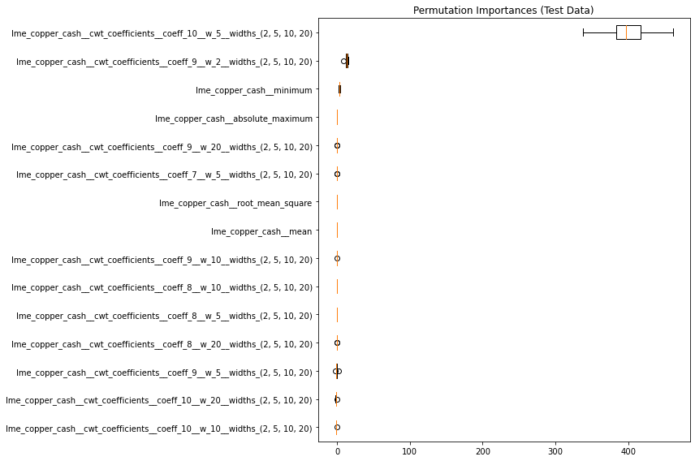

```python
# Visualisierung der Feature Importance für die 15 wichtigsten Features auf den Testdaten
sorted_idx = vip_rf.importances_mean[:15].argsort()

fig, ax = plt.subplots(figsize=(12,8))
ax.boxplot(
    vip_rf.importances[sorted_idx].T, vert=False, labels=x_test.columns[sorted_idx]
)
ax.set_title("Permutation Importances (Test Data)")
fig.tight_layout()
plt.show()
```

Dem Random Forest stehen zahlreiche Features zur Vorhersage der Zielvariable zur Verfügung. Den größten Anteil der Erklärungskraft zieht der Random Forest allerdings aus einem einzigen Feature, welches ein sehr starkes Übergewicht in der Feature Importance aufweist.

### Gradient Boosting Tree Regressor

```python
# Erstellen des Modells ohne Festlegung definierter Hyperparameter (Verwendung der Default-Werte)
xgb_regr = GradientBoostingRegressor(random_state=1234, verbose=True)
```

```python
# Trainieren des Modells
xgb_regr.fit(x_train, y_train)
```

```
      Iter       Train Loss   Remaining Time
         1      888674.4507            1.29s
         2      725672.3462            1.27s
         3      592904.6419            1.23s
         4      485089.3905            1.22s
         5      397111.0627            1.22s
         6      325169.8010            1.21s
         7      266677.8336            1.21s
         8      219051.2584            1.18s
         9      180267.8835            1.16s
        10      148446.5946            1.14s
        20       23963.8181            1.00s
        30        5706.5429            0.86s
        40        2326.4399            0.74s
        50        1314.7746            0.65s
        60         871.6285            0.53s
        70         626.5408            0.41s
        80         475.3933            0.27s
        90         383.9282            0.14s
       100         314.1885            0.00s
```

```
GradientBoostingRegressor(random_state=1234, verbose=True)
```

```python
# Anwenden des Modells auf die Testdaten
xgb_pred = xgb_regr.predict(x_test)
```

```python
# Kalkulieren des R2
xgb_regr.score(x_test,y_test)
```

```
0.956021095875742
```

```python
# Berechnung verschiedener Performancemetriken für die Vorhersage des XGB auf den Testdaten
determineRegressionMetrics(y_test, xgb_pred)
```

```
Mean absolute error = 91.05
Mean squared error = 18365.01
Median absolute error = 64.4
R2 score = 0.96
Root Mean Squared Logarithmic Error = 0.0210389712571677
```

#### Hyperparameteroptimierung mit GridSearch

```python
# Definition der Parameter und ihrer Wertebereiche für das Hyperparametertuning im Rahmen des Modelltrainings als Dict
# Das Parametertuning wurde mit größerem Wertebereich durchgeführt. Anschließend wurde der Wertebereich wieder verkleinert, um wiederholtes Trainieren des Modells zu beschleunigen.
xgb_param = {'n_estimators':[400],
            'max_depth':[10],
            'learning_rate':[0.05]
            ,'loss': ['absolute_error']}
```

```python
# Erstellen des GridSearch-Objekts
xgb_regr_gridsearch = GridSearchCV(xgb_regr, xgb_param, scoring='neg_mean_absolute_error')
```

```python
# Trainieren des Modells unter Verwendung der GridSearch-Methode mit 5-fold-cv
xgb_regr_gridsearch.fit(x_train, y_train)
```

```
      Iter       Train Loss   Remaining Time
         1         683.0795           11.17s
         2         649.9852           12.54s
         3         619.4028           10.19s
         4         589.9437            8.81s
         5         559.8072            7.74s
         6         531.0769            7.23s
         7         503.9594            6.79s
         8         477.1487            6.67s
         9         452.7043            6.43s
        10         430.3193            6.24s
        20         256.6357            6.18s
        30         156.1583            6.41s
        40          99.4507            6.97s
        50          65.6340            7.21s
```

[output cut: 123 more lines]

```
GridSearchCV(estimator=GradientBoostingRegressor(random_state=1234,
                                                 verbose=True),
             param_grid={'learning_rate': [0.05], 'loss': ['absolute_error'],
                         'max_depth': [10], 'n_estimators': [400]},
             scoring='neg_mean_absolute_error')
```

```python
# Ausgabe der besten Parameter aus dem Hyperparametertuning mit 5-fold-cross-validation
xgb_regr_gridsearch.best_params_
```

```
{'learning_rate': 0.05,
 'loss': 'absolute_error',
 'max_depth': 10,
 'n_estimators': 400}
```

```python
# Ausgabe der besten Performance (Mean Absolute Error) aus dem Hyperparametertuning mit 5-fold-cross-validation
xgb_regr_gridsearch.best_score_
```

```
-262.0266786053779
```

```python
# Ausgabe der Ergebnisse der Cross Validation
xgb_regr_gridsearch.cv_results_
```

```
{'mean_fit_time': array([12.23380952]),
 'std_fit_time': array([0.23129683]),
 'mean_score_time': array([0.00540161]),
 'std_score_time': array([0.00048969]),
 'param_learning_rate': masked_array(data=[0.05],
              mask=[False],
        fill_value='?',
             dtype=object),
 'param_loss': masked_array(data=['absolute_error'],
              mask=[False],
        fill_value='?',
             dtype=object),
 'param_max_depth': masked_array(data=[10],
              mask=[False],
        fill_value='?',
             dtype=object),
 'param_n_estimators': masked_array(data=[400],
              mask=[False],
        fill_value='?',
             dtype=object),
 'params': [{'learning_rate': 0.05,
   'loss': 'absolute_error',
   'max_depth': 10,
   'n_estimators': 400}],
 'split0_test_score': array([-833.48365536]),
 'split1_test_score': array([-82.55517638]),
 'split2_test_score': array([-118.22595217]),
 'split3_test_score': array([-168.18630393]),
 'split4_test_score': array([-107.68230518]),
 'mean_test_score': array([-262.02667861]),
 'std_test_score': array([287.08185134]),
 'rank_test_score': array([1])}
```

```python
# Prognose auf den Testdaten unter Verwendung der besten Modellparameter
xgb_grid_pred = xgb_regr_gridsearch.predict(x_test)
```

```python
# Bewertung der Prognoseergebnisse auf den Testdaten (Mean Absolute Error)
xgb_regr_gridsearch.score(x_test, y_test)
```

```
-101.44483402667716
```

```python
# Berechnung verschiedener Performancemetriken für das trainierte und auf den Testdaten evaluierte Modell
perf_xgb = determineRegressionMetrics(y_test,xgb_grid_pred)
perf_xgb
```

```
Mean absolute error = 101.44
Mean squared error = 18011.23
Median absolute error = 79.75
R2 score = 0.96
Root Mean Squared Logarithmic Error = 0.02159004364880073
```

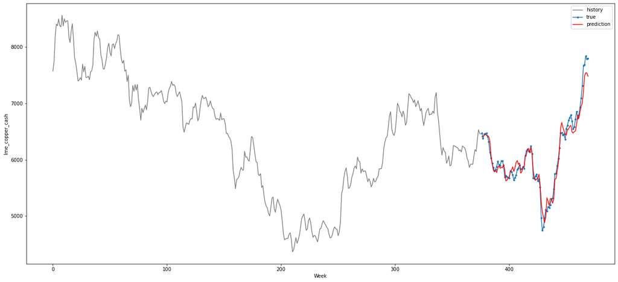

```python
# Visualisieren der gesamten Zeitreihe inkl. Prediction des XGB
plt.plot(np.arange(0, len(y_train)), y_train, '0.5', label="history")
plt.plot(np.arange(len(y_train), len(y_train) + len(y_test)), y_test, marker='.', label="true")
plt.plot(np.arange(len(y_train), len(y_train) + len(y_test)), xgb_grid_pred, 'r', label="prediction")
plt.ylabel('lme_copper_cash')
plt.xlabel('Week')
plt.legend()
plt.show();
```

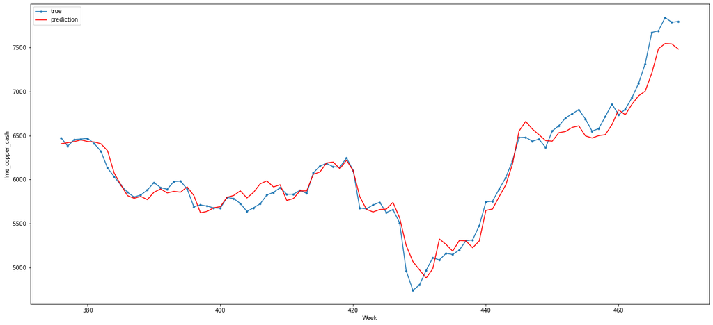

```python
# Visualisierung der Performance (Prognosegüte) auf den Testdaten
plt.plot(np.arange(len(y_train), len(y_train) + len(y_test)), y_test, marker='.', label="true")
plt.plot(np.arange(len(y_train), len(y_train) + len(y_test)), xgb_grid_pred, 'r', label="prediction")
plt.ylabel('lme_copper_cash')
plt.xlabel('Week')
plt.legend()
plt.show();
```

Der GradientBoostingTree passt sich in der Phase des rasant fallenden Kupferpreises im Zeitraum um die Woche 430 sehr schnell und relativ gut an - besser als der Random Forest. Allerdings hat auch der XGBoost bei sich kurzfristig ändernden Kupferpreisen und atypischen Entwicklungen, so z.B. in den letzten Wochen des Testdatensatzes Probleme bei der Anpassung und erzielt zwar bessere Vorhersageergebnisse als der Random Forest, allerdings ist auch hier der Fehlerwert deutlich höher als bei der Vorhersage der restlichen Datenpunkte der Testdaten.

#### Feature Importance beim XGBoost

```python
# Berechnung der Feature Importance des XGB-Regressors auf den Testdaten
vip = permutation_importance(xgb_regr_gridsearch, x_test, y_test, n_repeats=5,random_state=1234)
```

```python
# Ausgabe der durchschnittlichen Feature Importance über die 5 Durchläufe
vip.importances_mean
```

[output not shown]

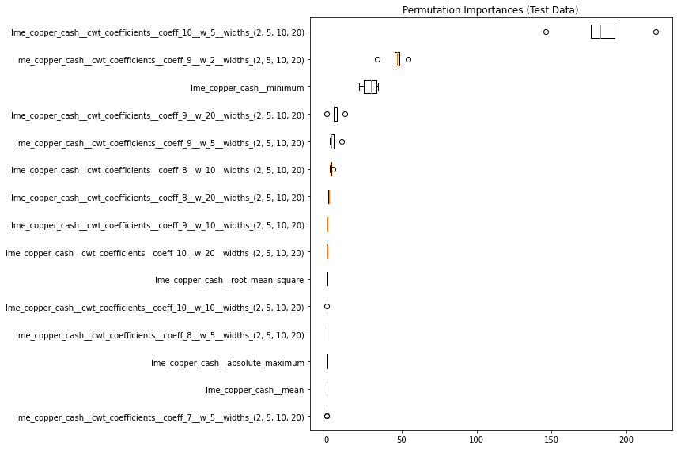

```python
# Visualisierung der Importance der 15 wichtigsten Features auf den Testdaten
sorted_idx = vip.importances_mean[:15].argsort()

fig, ax = plt.subplots(figsize=(12,8))
ax.boxplot(
    vip.importances[sorted_idx].T, vert=False, labels=x_test.columns[sorted_idx]
)
ax.set_title("Permutation Importances (Test Data)")
fig.tight_layout()
plt.show()
```

Anders als der Random Forest zieht der XGBoost die Erklärungskraft zur Vorhersage der Zielvariable (=Kupferpreis) aus mehreren Variablen und es ist davon auszugehen, dass der XGBoost aufgrund dieser Tatsache robustere Vorhersageergebnisse erzielt, als der Random Forest. Die Feature Importance schlägt bei mehreren Features nach oben aus - diese Features sind für den GradientBoostingTree besonders wichtig, wenn es um die Vorhersage unserer Zielvariable geht.

### Zusammenfassung Decision Trees

In diesem Abschnitt wurden zwei herkömmliche Machine Learning-Modelle auf Trainingsdaten trainiert und anschließend auf den zugehörigen Testdaten evaluiert.

Bei den beiden herkömmlichen Machine Learning-Modellen handelte es sich um Decision Trees, vertreten durch den Random Forest und den Gradient Boosting Tree (XGBoost).

Beide Modelle wurden auf den gleichen Trainings- und Testdatensets trainiert und evaluiert.

Zunächst wurden beide Modelle (sowohl der Random Forest, als auch der Gradient Boosting Tree) mit Default-Parametern trainiert. Beide Modelle schnitten gut, mit einem R2-Score von 0,925 (Random Forest) und 0,956 (Gradient Boosting Tree), ab.

Für beide Modelle wurde ein Hyperparametertuning implementiert. Das Hyperparametertuning wurde mit der GridSearch-Methode durchgeführt und mit einer k-fold-cross-validation (Default = 5 folds) kombiniert.

Das implementierte Hyperparametertuning brachte beim Random Forest, bei optimalen Parametern, noch eine kleine Verbesserung. Der R2-Score konnte auf 0,931 gehoben werden.

Beim GradientBoostingRegressor (XG Boost) konnte ebenfalls eine leichte, aber nicht signifikante, Verbesserung auf einen R2-Score von 0,957 erzielt werden.

Beide Modelle liefern auf den Testdaten also, auch bereits mit Default-Parametern, eine relativ gute Performance ab.

**Auffälligkeit bei beiden Modellen**: Im Rahmen der k-fold-cross-validation (hier: 5 folds) ist die Performance auf den einzelnen Folds (Splitfolgen in Trainings- und Validierungsdaten) sehr unterschiedlich und nicht sonderlich robust.

Es ist aber davon auszugehen, dass der Gradient Boosting Tree etwas robuster ist, als der Random Forest, da der Gradien Boosting Tree, wie man in der Feature Importance Analyse erkennen kann, für die Vorhersagen auf den Testdaten mehrere Features als besonders signifikant wahrnimmt, während beim Random Forest insbesondere ein Feature sehr dominant und signifikant für die Vorhersage der Kupferpreise auf den Testdaten zu sein scheint. Die Robustheit des XGB scheint demnach etwas größer zu sein, da er die Vorhersage aus mehreren höher gewichteten Features, und einer Mehrzahl an Features mit sehr geringer Gewichtung/Importance, ableitet.

## LSTM (Long short-term memory)

Das LSTM ist in der Informatik eine Technik, die zur Verbesserung der Entwicklung von künstlicher Intelligenz wesentlich beigetragen hat. Es ist eine Form der rekurrenten neuronalen Netze, die sich insbesondere für die Lösung von Zeitreihenproblemen (Zeitreihenprognose) besonders gut eignet.

Als Kontrast bzw. Vergleich zu den klassischen Machine Learning Modellen und dem CNN (Convolutional Neural Network) soll an dieser Stelle im Rahmen dieses Projektes die Umsetzung eines LSTM verprobt werden, um das vorliegende Zeitreihenproblem zu lösen.

### Data Preprocessing

Der Einsatz eines LSTM zur Prognose des Kupferpreises, mit dem von uns aufgebauten Dataset, verlangt noch einige Schritte im Rahmen des Data Preprocessings bevor die Daten für das LSTM genutzt werden können.

1. Das neuronale Netz kann nicht mit Pandas DataFrames trainiert und evaluiert werden. Die Datasets werden nach einem Split in Trainings- und Testdaten in Numpy-Arrays umgewandelt, um diese für das LSTM nutzbar zu machen.
2. Der Wertebereich der unterschiedlichen Variablen unseres Datasets ist teilweise sehr unterschiedlich, weshal eine Normalisierung/Standardisierung vorgenommen werden soll, um die Skalierung der einzelnen Features zu verkleinern. Dies war bei den Decision Tree's nicht notwendig, empfiehlt sich aber beim LSTM.

#### Normalisierung / Standardisierung der Features

Der Pandas Dataframe soll vollständig mithilfe der Min-Max-Normalisierung bearbeitet werden. Es gibt verschiedene Wege diese Form der Normalisierung vorzunehmen. Eine Funktion in der Skicit-Learn Library steht ebenfalls zur Verfügung: https://scikit-learn.org/stable/modules/generated/sklearn.preprocessing.MinMaxScaler.html.

```python
# Trainieren des MinMaxScalers für späteres Rescaling
df_target = pd.DataFrame(df['lme_copper_cash'])

scaler_target = MinMaxScaler()
scaler_target.fit(df_target)


df_input = df.loc[:, df.columns != 'lme_copper_cash']

scaler_input = MinMaxScaler()
scaler_input.fit(df_input)
```

```
MinMaxScaler()
```

```python
### Alternative Funktion für Min-Max-Scaling
def minmax_norm(df_input):
    return (df - df.min()) / ( df.max() - df.min())

df_new = minmax_norm(df)
```

```python
df_new.head()
```

| id | date | lme_copper_cash__cwt_coefficients__coeff_10__w_5__widths_(2, 5, 10, 20) | lme_copper_cash__cwt_coefficients__coeff_9__w_5__widths_(2, 5, 10, 20) | lme_copper_cash__cwt_coefficients__coeff_10__w_10__widths_(2, 5, 10, 20) | lme_copper_cash__cwt_coefficients__coeff_9__w_2__widths_(2, 5, 10, 20) | lme_copper_cash__cwt_coefficients__coeff_10__w_20__widths_(2, 5, 10, 20) | lme_copper_cash__cwt_coefficients__coeff_8__w_5__widths_(2, 5, 10, 20) | lme_copper_cash__cwt_coefficients__coeff_9__w_10__widths_(2, 5, 10, 20) | lme_copper_cash__cwt_coefficients__coeff_9__w_20__widths_(2, 5, 10, 20) | lme_copper_cash__cwt_coefficients__coeff_8__w_10__widths_(2, 5, 10, 20) | lme_copper_cash__cwt_coefficients__coeff_7__w_5__widths_(2, 5, 10, 20) | ... | lme_copper_stock__spkt_welch_density__coeff_2 | lme_copper_cash__permutation_entropy__dimension_6__tau_1 | lme_copper_stock__energy_ratio_by_chunks__num_segments_10__segment_focus_8 | lme_copper_cash__energy_ratio_by_chunks__num_segments_10__segment_focus_8 | lme_copper_stock__autocorrelation__lag_7 | lme_copper_cash__change_quantiles__f_agg_"var"__isabs_True__qh_0.8__ql_0.0 | lme_copper_stock__cwt_coefficients__coeff_4__w_5__widths_(2, 5, 10, 20) | lme_copper_stock__approximate_entropy__m_2__r_0.7 | lme_copper_stock__agg_linear_trend__attr_"rvalue"__chunk_len_10__f_agg_"mean" | lme_copper_cash |
| --- | --- | --- | --- | --- | --- | --- | --- | --- | --- | --- | --- | --- | --- | --- | --- | --- | --- | --- | --- | --- | --- | --- |
| 1 | 2012-01-08 | 0.461798 | 0.46226 | 0.449964 | 0.485251 | 0.453256 | 0.452844 | 0.447578 | 0.451423 | 0.445696 | 0.450889 | ... | 0.030459 | 1.0 | 0.0 | 0.0 | 0.374283 | 0.00000 | 0.298057 | 0.000000 | 0.0 | 0.764392 |
|  | 2012-01-15 | 0.461798 | 0.46226 | 0.449964 | 0.485251 | 0.453256 | 0.452844 | 0.447578 | 0.451423 | 0.445696 | 0.450889 | ... | 0.030459 | 1.0 | 0.0 | 0.0 | 0.374283 | 0.00000 | 0.298057 | 0.000000 | 0.0 | 0.805859 |
|  | 2012-01-22 | 0.461798 | 0.46226 | 0.449964 | 0.485251 | 0.453256 | 0.452844 | 0.447578 | 0.451423 | 0.445696 | 0.450889 | ... | 0.030459 | 1.0 | 0.0 | 0.0 | 0.374283 | 0.00000 | 0.298057 | 0.000000 | 0.0 | 0.910473 |
|  | 2012-01-29 | 0.461798 | 0.46226 | 0.449964 | 0.485251 | 0.453256 | 0.452844 | 0.447578 | 0.451423 | 0.445696 | 0.450889 | ... | 0.000033 | 1.0 | 0.0 | 0.0 | 0.374283 | 0.48185 | 0.298057 | 0.689281 | 0.0 | 0.962733 |
|  | 2012-02-05 | 0.461798 | 0.46226 | 0.449964 | 0.485251 | 0.453256 | 0.452844 | 0.447578 | 0.451423 | 0.445696 | 0.450889 | ... | 0.001148 | 1.0 | 0.0 | 0.0 | 0.374283 | 0.48185 | 0.109508 | 0.489052 | 0.0 | 0.955784 |

5 rows × 232 columns

#### Train-Test-Split

```python
# Trainingsdaten = 80%
# Testdaten = 20%
train_size = int(len(df_new) * 0.8)
test_size = len(df_new) - train_size
train, test = df_new.iloc[0:train_size], df_new.iloc[train_size:len(df_new)]
print(len(train), len(test))
```

```
376 94
```

```python
# Separieren von Input- und Output-Daten (x,y)
x_train = train.loc[:, df.columns != 'lme_copper_cash']
y_train1 = train['lme_copper_cash']

x_test = test.loc[:, df.columns != 'lme_copper_cash']
y_test1 = test['lme_copper_cash']
```

```python
x_train.head()
```

| id | date | lme_copper_cash__cwt_coefficients__coeff_10__w_5__widths_(2, 5, 10, 20) | lme_copper_cash__cwt_coefficients__coeff_9__w_5__widths_(2, 5, 10, 20) | lme_copper_cash__cwt_coefficients__coeff_10__w_10__widths_(2, 5, 10, 20) | lme_copper_cash__cwt_coefficients__coeff_9__w_2__widths_(2, 5, 10, 20) | lme_copper_cash__cwt_coefficients__coeff_10__w_20__widths_(2, 5, 10, 20) | lme_copper_cash__cwt_coefficients__coeff_8__w_5__widths_(2, 5, 10, 20) | lme_copper_cash__cwt_coefficients__coeff_9__w_10__widths_(2, 5, 10, 20) | lme_copper_cash__cwt_coefficients__coeff_9__w_20__widths_(2, 5, 10, 20) | lme_copper_cash__cwt_coefficients__coeff_8__w_10__widths_(2, 5, 10, 20) | lme_copper_cash__cwt_coefficients__coeff_7__w_5__widths_(2, 5, 10, 20) | ... | lme_copper_cash__partial_autocorrelation__lag_1 | lme_copper_stock__spkt_welch_density__coeff_2 | lme_copper_cash__permutation_entropy__dimension_6__tau_1 | lme_copper_stock__energy_ratio_by_chunks__num_segments_10__segment_focus_8 | lme_copper_cash__energy_ratio_by_chunks__num_segments_10__segment_focus_8 | lme_copper_stock__autocorrelation__lag_7 | lme_copper_cash__change_quantiles__f_agg_"var"__isabs_True__qh_0.8__ql_0.0 | lme_copper_stock__cwt_coefficients__coeff_4__w_5__widths_(2, 5, 10, 20) | lme_copper_stock__approximate_entropy__m_2__r_0.7 | lme_copper_stock__agg_linear_trend__attr_"rvalue"__chunk_len_10__f_agg_"mean" |
| --- | --- | --- | --- | --- | --- | --- | --- | --- | --- | --- | --- | --- | --- | --- | --- | --- | --- | --- | --- | --- | --- | --- |
| 1 | 2012-01-08 | 0.461798 | 0.46226 | 0.449964 | 0.485251 | 0.453256 | 0.452844 | 0.447578 | 0.451423 | 0.445696 | 0.450889 | ... | 0.825697 | 0.030459 | 1.0 | 0.0 | 0.0 | 0.374283 | 0.00000 | 0.298057 | 0.000000 | 0.0 |
|  | 2012-01-15 | 0.461798 | 0.46226 | 0.449964 | 0.485251 | 0.453256 | 0.452844 | 0.447578 | 0.451423 | 0.445696 | 0.450889 | ... | 0.825697 | 0.030459 | 1.0 | 0.0 | 0.0 | 0.374283 | 0.00000 | 0.298057 | 0.000000 | 0.0 |
|  | 2012-01-22 | 0.461798 | 0.46226 | 0.449964 | 0.485251 | 0.453256 | 0.452844 | 0.447578 | 0.451423 | 0.445696 | 0.450889 | ... | 0.825697 | 0.030459 | 1.0 | 0.0 | 0.0 | 0.374283 | 0.00000 | 0.298057 | 0.000000 | 0.0 |
|  | 2012-01-29 | 0.461798 | 0.46226 | 0.449964 | 0.485251 | 0.453256 | 0.452844 | 0.447578 | 0.451423 | 0.445696 | 0.450889 | ... | 0.650933 | 0.000033 | 1.0 | 0.0 | 0.0 | 0.374283 | 0.48185 | 0.298057 | 0.689281 | 0.0 |
|  | 2012-02-05 | 0.461798 | 0.46226 | 0.449964 | 0.485251 | 0.453256 | 0.452844 | 0.447578 | 0.451423 | 0.445696 | 0.450889 | ... | 0.773090 | 0.001148 | 1.0 | 0.0 | 0.0 | 0.374283 | 0.48185 | 0.109508 | 0.489052 | 0.0 |

5 rows × 231 columns

#### Formatierung und Umwandlung des DataFrames in NumpyArrays für Supervised Learning

```python
def create_dataset(X, y, time_steps=1):
    Xs, ys = [], []
    for i in range(len(X) - time_steps):
        v = X.iloc[i:(i + time_steps)].values
        Xs.append(v)
        ys.append(y.iloc[i + time_steps])
    return np.array(Xs), np.array(ys)
```

```python
time_steps = 25 # Hyperparameter, der getunt werden kann

# reshape to [samples, time_steps, n_features]

X_train, y_train = create_dataset(x_train, y_train1, time_steps)
X_test, y_test = create_dataset(x_test, y_test1, time_steps)

print(X_train.shape, y_train.shape)
print(X_test.shape, y_test.shape)
```

```
(351, 25, 231) (351,)
(69, 25, 231) (69,)
```

### LSTM

#### Aufbau der Architektur des Modells

```python
model = keras.Sequential()
model.add(keras.layers.LSTM(units=32,input_shape=(X_train.shape[1], X_train.shape[2])))
model.add(keras.layers.Dense(units=1))
model.compile(loss='mae', optimizer='adam')
```

```python
model.summary()
```

```
Model: "sequential"
_________________________________________________________________
 Layer (type)                Output Shape              Param #
=================================================================
 lstm (LSTM)                 (None, 32)                33792

 dense (Dense)               (None, 1)                 33

=================================================================
Total params: 33,825
Trainable params: 33,825
Non-trainable params: 0
_________________________________________________________________
```

#### Trainieren des Modells

```python
history = model.fit(
    X_train, y_train,
    epochs=30,
    batch_size=32,
    validation_data = (X_test,y_test),
    verbose=True,
    shuffle=False
)
```

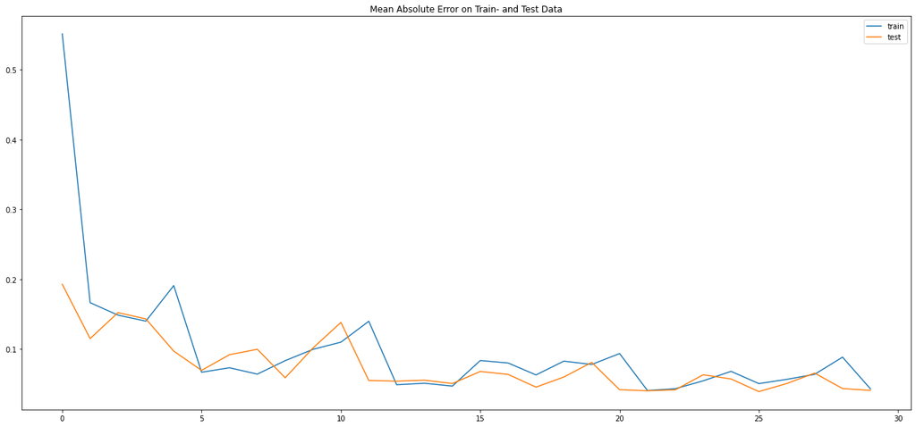

```python
# Visualisierung des Lernfortschritts des LSTM über die eingestellte Anzahl an Epochen auf Trainings- und Testdaten

plt.plot(history.history['loss'], label='train')
plt.plot(history.history['val_loss'], label='test')
plt.title('Mean Absolute Error on Train- and Test Data')
plt.legend();
```

#### Hyperparameteroptimierung beim LSTM

```python
# Defintion einer Funktion zur Definition des Modells und dessen Architektur
def create_lstm():
    # Vorbereiten der Architektur des LSTM
    model = keras.Sequential()
    model.add(keras.layers.LSTM(units=32,input_shape=(X_train.shape[1], X_train.shape[2])))
    # model.add(keras.layers.Dropout(rate=0.3))
    model.add(keras.layers.Dense(units=1))


    # Kompilieren des Modells und Angabe wichtiger Hyperparameter für das Modelltraining
    model.compile(loss='mae', optimizer='adam')
    return model
```

```python
lstm_model = KerasRegressor(build_fn=create_lstm, verbose = 1)
```

```python
# Definition und Anwendung der Grid für die Hyperparameteroptimierung (Wertebereiche für das Tuning)
param_grid = dict(epochs=[10,20,30,40], batch_size=[2,4, 8,16, 32])
grid = GridSearchCV(estimator=lstm_model, scoring='neg_mean_absolute_error', param_grid=param_grid, cv=3)

# Trainieren des Modells mit der definierten Grid und 3-fold-cross validation
grid_result = grid.fit(X_train, y_train)
```

```python
# Performance je Hyperparameterkombination
grid_result.cv_results_
```

```
{'mean_fit_time': array([ 6.95379512, 11.47900375, 15.96509933, 22.33694696,  5.65973846,
        10.16492105, 12.20744109, 16.6081086 ,  4.19588248,  6.06374439,
         8.57438914,  9.24420969,  3.595752  ,  4.21140305,  5.17145642,
         6.28572917,  2.89070034,  3.57458679,  4.19015733,  4.7927866 ]),
 'std_fit_time': array([0.29501373, 0.41382331, 0.36400252, 1.89513896, 0.13627907,
        2.11349279, 0.17868273, 0.68193922, 0.1606012 , 0.32520633,
        0.58895   , 0.11966448, 0.29822534, 0.15237055, 0.13444625,
        0.45197953, 0.16933347, 0.14684736, 0.10812137, 0.16151436]),
 'mean_score_time': array([0.63874467, 0.65102235, 0.54024363, 0.55479225, 0.55325937,
        0.58759244, 0.59120663, 0.62462417, 0.605335  , 0.49571983,
        0.63860981, 0.45145496, 0.62341889, 0.45950937, 0.57922117,
        0.43416023, 0.52704477, 0.46315908, 0.56284165, 0.45105553]),
 'std_score_time': array([0.10227466, 0.12529855, 0.01596693, 0.03844879, 0.10991   ,
        0.13446955, 0.13508285, 0.06448707, 0.1643756 , 0.00782204,
        0.20100292, 0.0163807 , 0.16473422, 0.01804754, 0.11923139,
        0.00862135, 0.1477247 , 0.02684842, 0.14124314, 0.01695699]),
 'param_batch_size': masked_array(data=[2, 2, 2, 2, 4, 4, 4, 4, 8, 8, 8, 8, 16, 16, 16, 16, 32,
                    32, 32, 32],
              mask=[False, False, False, False, False, False, False, False,
                    False, False, False, False, False, False, False, False,
                    False, False, False, False],
        fill_value='?',
             dtype=object),
 'param_epochs': masked_array(data=[10, 20, 30, 40, 10, 20, 30, 40, 10, 20, 30, 40, 10, 20,
                    30, 40, 10, 20, 30, 40],
              mask=[False, False, False, False, False, False, False, False,
                    False, False, False, False, False, False, False, False,
                    False, False, False, False],
        fill_value='?',
             dtype=object),
 'params': [{'batch_size': 2, 'epochs': 10},
  {'batch_size': 2, 'epochs': 20},
  {'batch_size': 2, 'epochs': 30},
  {'batch_size': 2, 'epochs': 40},
  {'batch_size': 4, 'epochs': 10},
  {'batch_size': 4, 'epochs': 20},
  {'batch_size': 4, 'epochs': 30},
  {'batch_size': 4, 'epochs': 40},
  {'batch_size': 8, 'epochs': 10},
  {'batch_size': 8, 'epochs': 20},
```

[output cut: 17 more lines]

```
        -0.07139041, -0.10928576, -0.07989508, -0.04772108, -0.05041815]),
 'split2_test_score': array([-0.09197433, -0.03726859, -0.03882744, -0.04609953, -0.0743582 ,
        -0.04126424, -0.03422739, -0.03621934, -0.06517308, -0.03335363,
        -0.05172548, -0.03015847, -0.0563254 , -0.04513461, -0.05717058,
        -0.06178027, -0.04806463, -0.03813155, -0.04717432, -0.03665224]),
 'mean_test_score': array([-0.07606744, -0.06006694, -0.04756634, -0.05493962, -0.08483869,
        -0.05272227, -0.05886943, -0.04764629, -0.08454645, -0.0511368 ,
        -0.05306717, -0.05171793, -0.08905961, -0.06727197, -0.07302028,
        -0.08770925, -0.1002689 , -0.08984763, -0.05180998, -0.04795947]),
 'std_test_score': array([0.01168666, 0.02044555, 0.0121768 , 0.01782178, 0.01272454,
        0.01006428, 0.01755959, 0.01432327, 0.04283117, 0.02105268,
        0.00621729, 0.01752487, 0.02373236, 0.01602249, 0.02295217,
        0.03013025, 0.03946198, 0.04682103, 0.00617323, 0.00841022]),
 'rank_test_score': array([14, 11,  1,  9, 16,  7, 10,  2, 15,  4,  8,  5, 18, 12, 13, 17, 20,
        19,  6,  3])}
```

```python
# Zusammenfassung der Hyperparameteroptimierung
print(grid_result.best_score_)
print(grid_result.best_params_)
```

```
-0.047566340124768486
{'batch_size': 2, 'epochs': 30}
```

#### Evaluation des LSTM

```python
# Vorhersage auf den Testdaten mit dem Modell aus dem Hyperparametertuning (bei optimalen Parametern)
lstm_grid_pred = grid_result.predict(X_test)
```

```python
# Aufheben der Normalisierung (Rescaling) der Vorhersagewerte
lstm_grid_pred1 = lstm_grid_pred.reshape((len(lstm_grid_pred), 1))
lstm_grid_pred_rescaled = scaler_target.inverse_transform(lstm_grid_pred1)

# Aufheben der Normalisierung (Rescaling) der tatsächlichen Kupferpreise
lstm_grid_actual = y_test.reshape((len(y_test), 1))
lstm_grid_actual_rescaled = scaler_target.inverse_transform(lstm_grid_actual)
```

```python
# Kalkulieren der Metriken für die aktuelle Vorhersage auf den Testdaten
perf_lstm = determineRegressionMetrics(lstm_grid_actual_rescaled,lstm_grid_pred_rescaled)
```

```
Mean absolute error = 128.12
Mean squared error = 29067.07
Median absolute error = 84.06
R2 score = 0.95
Root Mean Squared Logarithmic Error = 0.027923230960296686
```

Auf den Testdaten liegt der R2-Score des LSTM bei 0.95 und ist damit ziemlich gleichauf mit dem Gradient Boosting Tree. Der MAE ist nicht signifikant, nur leicht, schlechter, als beim XGB.

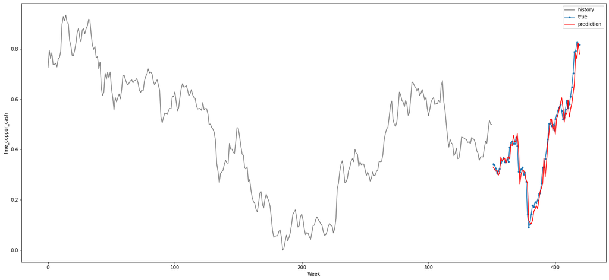

```python
# Visualisieren der gesamten Zeitreihe inkl. Prediction
plt.plot(np.arange(0, len(y_train)), y_train, '0.5', label="history")
plt.plot(np.arange(len(y_train), len(y_train) + len(y_test)), y_test, marker='.', label="true")
plt.plot(np.arange(len(y_train), len(y_train) + len(y_test)), lstm_grid_pred, 'r', label="prediction")
plt.ylabel('lme_copper_cash')
plt.xlabel('Week')
plt.legend()
plt.show();
```

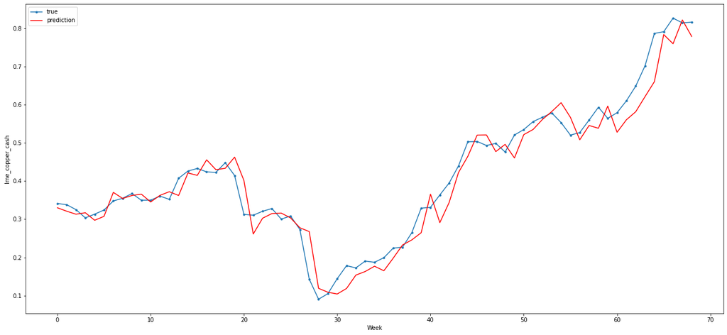

```python
# Visualisierung der Performance (Prognosegüte) auf den Testdaten
plt.plot(y_test, marker='.', label="true")
plt.plot(lstm_grid_pred, 'r', label="prediction")
plt.ylabel('lme_copper_cash')
plt.xlabel('Week')
plt.legend()
plt.show();
```

In unseren Daten, das muss ergänzend auch erwähnt werden, versuchen wir auf den Testdaten eine stark von den Trainingsdaten abweichende Statistik vorherzusagen. Der hier in den Testdaten enthaltene Zeitraum beinhaltet u.a. die in 2020 eingetretene Corona-Krise. Insbesondere zu Beginn der Corona Krise fielen auch die Kupferpreise stark und erholten sich danach ebenso stark und ungewöhnlich schnell wieder.

## Gesamtfazit zu den Modellen (LSTM & Decision Trees)

Das LSTM performt im hier vorliegenden Beispiel sehr gut. Demgegenüber steht die Performance der eingangs trainierten und evaluierten klassischen Machine Learning Modelle, vertreten durch die Decision Tree's (den Random Forest und den Gradient Boosting Tree).

Im Folgenden sollen die implementierten Modelle zusammenfassend unter definierten Aspekten betrachtet werden.

**Performance:**

Die Performance aller Modelle auf den Testdaten, nach dem sie auf die gleiche Sequenz an Trainingsdaten trainiert wurden, ist vergleichbar gut. Visuell überzeugt die Vorhersagegenauigkeit und Anpassungsfähigkeit des LSTM auf den Testdaten, bei aber insgesamt sehr mit den Decision Tree's vergleichbaren Performancemetriken, etwas mehr.

An dieser Stelle hat ein sehr einfaches LSTM bereits sehr gute Ergebnisse auf den Testdaten geliefert. Ein R2 von 0.95 entspricht einer mit dem XGBoost vergleichbare Performance auf den Testdaten.

Allerdings fällt im Rahmen des Modelltrainings des LSTM mit 3-fold-cross-validation und Hyperparametertuning auf, dass die Vorhersageperformance des LSTM über die einzelnen Trainingsiterationen (3 Folds) robuster war, als das beim Random Forest und XGBoost der fall war (s. Zusammenfassung zu den Decision Tree's).

**Geschwindigkeit:**

Da das LSTM an dieser Stelle nicht besonders komplex ist, ist die Dauer des Modelltrainings auch nicht besonders lang. Das Trainieren des neuronalen Netzes nimmt nicht mehr Zeit in Anspruch, als das bei den Decision Tree's der Fall ist - eben weil es nicht besonders komplex ist.

Die Trainingsdauer aller Modelle wird stark beeinflusst durch die Anzahl der Folds in der k-fold-cross-validation während des Modelltrainings und ebenso wird die Trainingsdauer stark durch die Wertebereiche und Anzahl der zu tunenden Parameter beeinflusst.

Der XGBoost (Gradient Boosting Tree) hat bei ausgeprägtem Hyperparametertuning mit k-fold-cross-validation eine relativ lange Trainingsdauer, liefert allerdings grundsätzlich auch gute Ergebnisse zurück. Beim LSTM können ebenfalls beliebig viele Parameter getunt werden, beispielhaft und testweise wurden in diesem Fall die Batch Size und die Anzahl der Trainingsepochen als Parameter getunt. Hierüber konnte, nach erstem manuellen Testen, relativ schnell bessere Vorhersageergebnisse erzielt werden.

Wird die Anzahl der zu optimierenden Hyperaparameter beim LSTM erhöht und mithilfe der GridSearch-Methode optimiert, wird das LSTM erwartungsgemäß eine exponentiell steigende Trainingszeit beanspruchen. LSTM's, wie andere neuronale Netze ebenso, verfügen über eine Vielzahl an Parametern, die angepasst und optimiert werden können.

**Erklärbarkeit:**

Insgesamt funktioniert das LSTM, sowohl hinsichtlich der Trainingsdauer mit Hyperparametertuning, als auch hinsichtlich der letztendlichen Performance des Modells während des Modelltrainings und auf den Testdaten, sehr gut.

Einziges Manko: Die Erklärbarkeit des Modells. Der Decision Tree (egal ob XGBoost oder Random Forest) ist relativ gut erklärbar. Das Konstrukt eines Decision Tree's lässt sich gegenüber Nicht-Data-Scientisten leichter erklären, als die Funktionsweise und der Aufbau eines LSTM (rekurrentes neuronales Netz mit Long-Short-Term-Memory). Bei Bedarf gibt es Mittel und Wege einzelne Bestandteile des Entscheidungsbaums zu visualisieren und exemplarisch für die Erklärung der Vorgehensweise des Modells verwenden.

Bei vergleichbarer Performance auf den Testdaten wäre, aus Gründen der Erklärbarkeit und Nachvollziehbarkeit, vermutlich ein Decision Tree Modell im praktischen Einsatz zu bevorzugen.

## ARIMA (Auto-Regressive Integrated Moving Average)

ARIMA ist ein Akronym und steht für **A**uto-**R**egressive **I**ntegrated **M**oving **A**verage. Es gehört durch seine Einfachheit zu den bekanntesten und weit verbreitetsten Prognose-Modellen bei Zeitreihen-Daten. Das ARIMA-Modell kombiniert Autoregressive-Prozesse (AR-Prozesse) und Moving Average-Prozesse (MA-Prozesse). Aufgrund seiner Bedeutung soll es nun als mögliches Lösungsmodell im Rahmen dieses Projekts verwendet werden, sowohl als univariate als auch als multivariate Variante.

In Python gibt es die Möglichkeit, ein ARIMA Modell selbständig aufzubauen, d.h. AR(p), I(d) und MA(q) müssen manuell bestimmt werden, oder AutoARIMA zu verwenden, bei dem dieser Schritt entfällt.

Für den Einsatz des ARIMA-Modells im Projekt ergeben sich damit folgende Szenarien:

Univariate ARIMA:

- manuell
- AutoARIMA

Multivariate ARIMA:

- manuell
- AutoARIMA

```python
import pandas as pd
import numpy as np
from matplotlib import pyplot as plt
from pylab import rcParams
from sklearn.metrics import mean_squared_error, r2_score
from sklearn.metrics import mean_absolute_error,  median_absolute_error
from tensorflow import keras
from numpy import array
from keras.models import Sequential
from keras.layers import Dense
from keras.layers import Flatten
from keras.layers.convolutional import Conv1D
from keras.layers.convolutional import MaxPooling1D
from tensorflow.keras.optimizers import SGD
```

```python
rcParams['figure.figsize'] = 22, 10
```

### Modeling: Univariate Zeitreihen mit ARIMA

Beim univariaten ARIMA Modell verändert sich nur eine Variable über die Zeit, in diesem Fall die Zielvariable "lme_copper_cash".

- *AR - Autoregressiv (p)*: Anzahl zurückliegenden Werte (=autoregressiver Ordnungen) der Zeitreihe, die für die Vorhersage der aktuellen Werte verwendet werden.
- *I - Differenz (d)*: Ordnung der Differenzierung. Im ARIMA Modell wird Stationarität angenommen. Mit der Differenzierung wird die bei Trends überlicherweise vorliegende Nicht-Stationarität herausgenommen.
- *MA - Gleitender Durchschnitt (q)*: Ordnungen des gleitenden Durchschnitts, die angeben, wie Abweichungen vom Mittelwert der Zeitreihe für zurückliegende Werte für die Vorhersage der aktuellen Werte verwendet werden.

**Data Preparation**

```python
# Import data from Feature Engineering

df_input_output = pd.read_csv('https://raw.githubusercontent.com/andreashrb/Python_for_ML_Project/main/data/input_output_data.csv', sep=',', encoding='utf-8')
```

```python
# Evaluations-Metriken für die ARIMA-Modelle

def forecast_metrics (forecast, test):
    mape = np.mean(np.abs(forecast - test)/np.abs(test))
    me = np.mean(forecast - test)
    mae = np.mean(np.abs(forecast - test))
    mpe = np.mean((forecast - test)/test)
    rmse = np.mean((forecast - test)**2)**.5

    print('Mean absolute percentage error: %f' % mape)
    print('Mean error: %f' % me)
    print('Mean absolute error: %f' % mae)
    print('Mean percentage Error: %f' % mpe)
    print('Root Mean Squared Error: %f' % rmse)
```

```python
# Define dataset

df_un_arima = df_input_output.loc[:,['date','lme_copper_cash']]
df_un_arima.set_index('date',inplace=True)

df_un_arima.head()
```

| date | lme_copper_cash |
| --- | --- |
| 2012-01-08 | 7574.75 |
| 2012-01-15 | 7749.00 |
| 2012-01-22 | 8188.60 |
| 2012-01-29 | 8408.20 |
| 2012-02-05 | 8379.00 |

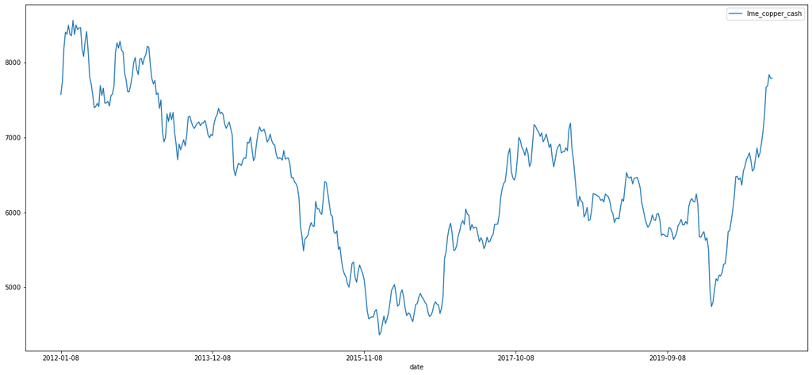

```python
# Plot data

plt.figure(figsize=(12,5), dpi=100)
df_un_arima.plot()
```

```python
# Check if stationary

from statsmodels.tsa.stattools import adfuller

result = adfuller(df_un_arima.lme_copper_cash)

print('ADF Statistic: %f' % result[0])
print('p-value: %f' % result[1])
print('Critical Values:')
for key, value in result[4].items():
    print('\t%s: %.3f' % (key, value))
```

```
ADF Statistic: -1.897082
p-value: 0.333435
Critical Values:
	1%: -3.444
	5%: -2.868
	10%: -2.570
```

**Interpretation**:

Je negativer der ADF-Wert (Augmented Dickey Fuller Wert), desto wahrscheinlicher ist es, dass wir die Nullhypothese ablehnen und einen stationären Datensatz besitzen. In unserem Fall liegt diese bereits nahe bei 0, sodass wir die Nullhypothese mit einer geringeren Wahrscheinlichkeit ablehnen. Daneben ist er deutlich größer als die kritischen Werte, wodurch sich das Vorhandensein einer Nicht-Stationarität bereits verdichtet. Der p-value von 0.33 bestätigt dies, da bei einem p-value > 0,05 die Nullhypothese nicht abgelehnt werden kann (=Daten besitzen Einheitswurzel). Es liegt somit ein nicht-stationärer Datensatz vor.

Daher soll nun im Folgenden so lange eine Differenzierung stattfinden, bis die Nullhypothese abgelehnt wird (=Vorliegen von Stationarität).

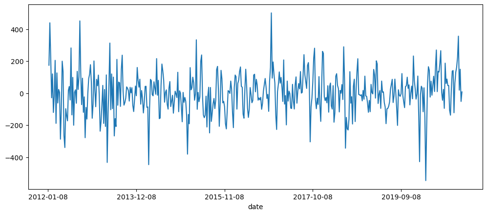

```python
# Differencing of series to transform non-stationary to stationary (d parameter)

df_un_arima_diff = df_un_arima.copy()

df_un_arima_diff['1_diff']=df_un_arima_diff['lme_copper_cash']-df_un_arima_diff['lme_copper_cash'].shift(1)


plt.figure(figsize=(12,5), dpi=100)
df_un_arima_diff['1_diff'].plot()
```

```python
# ADF-Test of 1. Differencing

result= adfuller(df_un_arima_diff['1_diff'].dropna())

print('ADF Statistic: %f' % result[0])
print('p-value: %f' % result[1])
print('Critical Values:')
for key, value in result[4].items():
    print('\t%s: %.3f' % (key, value))
```

```
ADF Statistic: -16.358392
p-value: 0.000000
Critical Values:
	1%: -3.444
	5%: -2.868
	10%: -2.570
```

**Bewertung**:

Der p-value ist kleiner als 0,05, womit bereits nach der ersten Differenzierung eine Stationarität vorliegt.

Daher: **d=1**

[figure not shown]

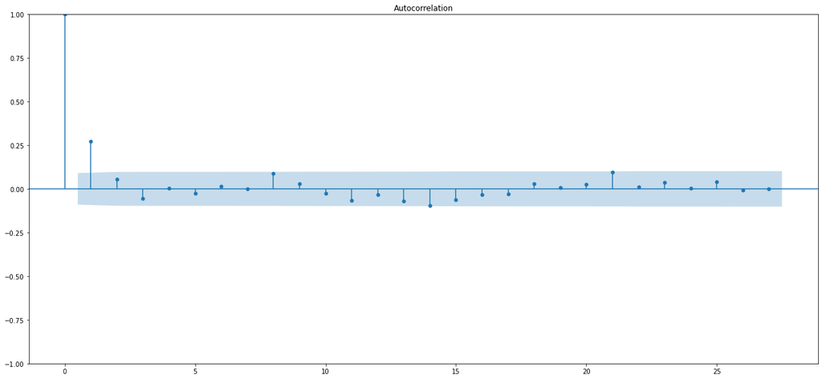

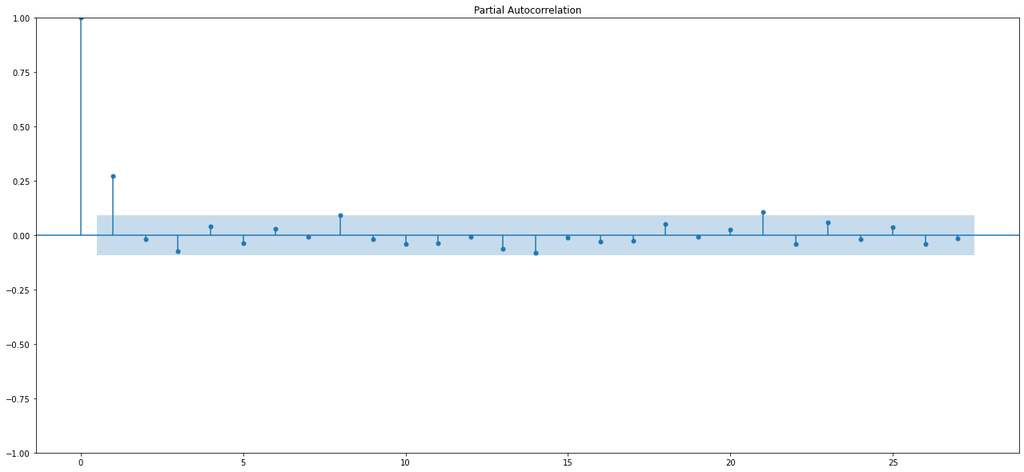

```python
# Autocorrelation and partial Autocorrelation (p and q parameters)

from statsmodels.graphics.tsaplots import plot_acf, plot_pacf

plot_acf(df_un_arima_diff['1_diff'].dropna())
plot_pacf(df_un_arima_diff['1_diff'].dropna())
```

**Bewertung**:

Zur Bestimmung der Ordnung von AR (p) und MA (q) werden folgende Regeln herangezogen: https://people.duke.edu/~rnau/arimrule.htm

Für unsere Anwendung bedeutet das konkret: Sowohl bei der partiellen, als auch der normalen Autokorrelation ist der Grenzwert, der noch über der Signifikanzlinie liegt, bei 1.

Daher **p=1** und **q=1**

Mit der Bestimmung der Paramter kann nun mit der Modellbildung begonnen werden.

```python
# Set 'date' as datetime

df_un_arima = df_un_arima.reset_index()
df_un_arima['date'] = pd.to_datetime(df_un_arima['date'])
df_un_arima = df_un_arima.set_index('date')

df_un_arima.head()
```

| date | lme_copper_cash |
| --- | --- |
| 2012-01-08 | 7574.75 |
| 2012-01-15 | 7749.00 |
| 2012-01-22 | 8188.60 |
| 2012-01-29 | 8408.20 |
| 2012-02-05 | 8379.00 |

```python
# Split data into train and test

size = int(len(df_un_arima) * 0.8)

train, test = df_un_arima[0:size].squeeze(), df_un_arima[size:len(df_un_arima)].squeeze()
```

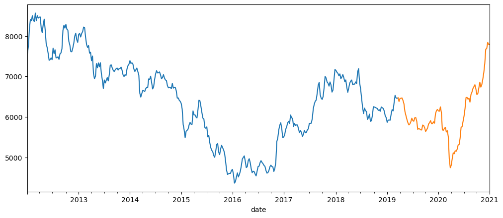

```python
# Show train and test

plt.figure(figsize=(12,5), dpi=100)

train.plot()
test.plot()
```

```python
# Change index to right format

train.index = pd.DatetimeIndex(train.index.values, freq=train.index.inferred_freq)
test.index = pd.DatetimeIndex(test.index.values, freq=test.index.inferred_freq)
```

```python
# Build model with order = 1,1,1

from statsmodels.tsa.arima.model import ARIMA

model = ARIMA(train, order=(1, 1, 1))

model_fit = model.fit()

print(model_fit.summary())
```

```
                               SARIMAX Results
==============================================================================
Dep. Variable:        lme_copper_cash   No. Observations:                  376
Model:                 ARIMA(1, 1, 1)   Log Likelihood               -2346.250
Date:                Sun, 01 May 2022   AIC                           4698.501
Time:                        21:34:37   BIC                           4710.281
Sample:                    01-08-2012   HQIC                          4703.178
                         - 03-17-2019
Covariance Type:                  opg
==============================================================================
                 coef    std err          z      P>|z|      [0.025      0.975]
------------------------------------------------------------------------------
ar.L1          0.2314      0.193      1.200      0.230      -0.147       0.609
ma.L1          0.0127      0.196      0.065      0.948      -0.372       0.397
sigma2      1.594e+04    927.693     17.183      0.000    1.41e+04    1.78e+04
===================================================================================
Ljung-Box (L1) (Q):                   0.00   Jarque-Bera (JB):                24.15
Prob(Q):                              0.95   Prob(JB):                         0.00
Heteroskedasticity (H):               0.69   Skew:                            -0.02
Prob(H) (two-sided):                  0.04   Kurtosis:                         4.24
===================================================================================

Warnings:
[1] Covariance matrix calculated using the outer product of gradients (complex-step).
```

**Bewertung:**

Sowohl ar.L1 als auch ma.L1 weisen p-values auf, die über dem Signifikanzniveau von 0.05 liegen. Man kann daraus schließen, dass die Koeffizienten sowohl für den autoregressiven Term als auch für den gleitenden Durchschnitt statistisch nicht signifikant sind.

Im Folgenden wird daher ein weiteres Modell mit veränderten Parametern trainiert.

```python
# Build model with order = 1,2,1

from statsmodels.tsa.arima.model import ARIMA

model = ARIMA(train, order=(1, 2, 1))
model_fit = model.fit()

print(model_fit.summary())
```

```
                               SARIMAX Results
==============================================================================
Dep. Variable:        lme_copper_cash   No. Observations:                  376
Model:                 ARIMA(1, 2, 1)   Log Likelihood               -2344.598
Date:                Sun, 01 May 2022   AIC                           4695.195
Time:                        21:34:37   BIC                           4706.968
Sample:                    01-08-2012   HQIC                          4699.869
                         - 03-17-2019
Covariance Type:                  opg
==============================================================================
                 coef    std err          z      P>|z|      [0.025      0.975]
------------------------------------------------------------------------------
ar.L1          0.2482      0.055      4.530      0.000       0.141       0.356
ma.L1         -0.9999      0.478     -2.092      0.036      -1.937      -0.063
sigma2      1.597e+04   7657.708      2.085      0.037     959.633     3.1e+04
===================================================================================
Ljung-Box (L1) (Q):                   0.01   Jarque-Bera (JB):                22.91
Prob(Q):                              0.92   Prob(JB):                         0.00
Heteroskedasticity (H):               0.68   Skew:                            -0.16
Prob(H) (two-sided):                  0.03   Kurtosis:                         4.17
===================================================================================

Warnings:
[1] Covariance matrix calculated using the outer product of gradients (complex-step).
```

**Bewertung:**

Sowohl ar.L1 als auch ma.L1 weisen nun p-values < 0.05 auf, wodurch eine statistische Signifikanz unterstellt werden kann. Daneben hat sich auch der AIC - Akaike’s Information Criterion - leicht verbessert.

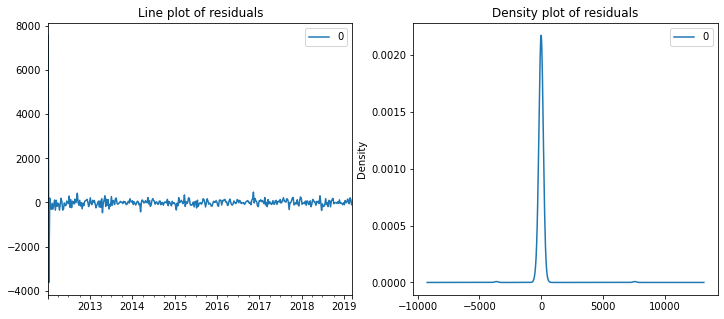

```python
# residual plots

residuals = pd.DataFrame(model_fit.resid)
fig, ax = plt.subplots(1,2,figsize=(12,5))

residuals.plot(title="Line plot of residuals", ax=ax[0])
residuals.plot(kind='kde', title='Density plot of residuals', ax=ax[1])
plt.show()
```

**Bewertung:**

Der Standardfehler liegt nahezu bei 0 und weist eine geringe Streuung auf. Das heißt konkret, dass die prognostizierten Werte der Trainingsdaten im Schnitt sehr nahe an den bzw. nahe um die tatsächlichen Werten liegen.

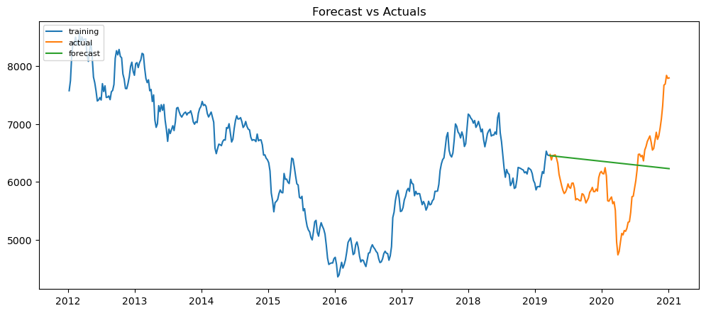

```python
# Plot forecast vs. Actual

fc = model_fit.forecast(94, alpha=0.05)

fc_series = pd.Series(fc, index=test.index)

plt.figure(figsize=(12,5), dpi=100)
plt.plot(train, label='training')
plt.plot(test, label='actual')
plt.plot(fc_series, label='forecast')

plt.title('Forecast vs Actuals')
plt.legend(loc='upper left', fontsize=8)
plt.show()
```

```python
# Comparison of forecast vs. test (=actual) per week

df_comp_fore_test = pd.merge(fc, test, right_index=True, left_index=True)

df_comp_fore_test['difference_fc_test'] = df_comp_fore_test['predicted_mean'] - df_comp_fore_test['lme_copper_cash']

df_comp_fore_test.head(20)
```

|  | predicted_mean | lme_copper_cash | difference_fc_test |
| --- | --- | --- | --- |
| 2019-03-24 | 6454.705713 | 6474.800 | -20.094287 |
| 2019-03-31 | 6451.929669 | 6379.500 | 72.429669 |
| 2019-04-07 | 6449.431153 | 6455.000 | -5.568847 |
| 2019-04-14 | 6447.001515 | 6460.000 | -12.998485 |
| 2019-04-21 | 6444.588971 | 6468.250 | -23.661029 |
| 2019-04-28 | 6442.180670 | 6409.000 | 33.180670 |
| 2019-05-05 | 6439.773422 | 6322.000 | 117.773422 |
| 2019-05-12 | 6437.366435 | 6131.125 | 306.241435 |
| 2019-05-19 | 6434.959513 | 6033.100 | 401.859513 |
| 2019-05-26 | 6432.552607 | 5937.600 | 494.952607 |
| 2019-06-02 | 6430.145706 | 5856.125 | 574.020706 |
| 2019-06-09 | 6427.738805 | 5801.500 | 626.238805 |
| 2019-06-16 | 6425.331904 | 5824.900 | 600.431904 |
| 2019-06-23 | 6422.925004 | 5880.500 | 542.425004 |
| 2019-06-30 | 6420.518103 | 5966.800 | 453.718103 |
| 2019-07-07 | 6418.111202 | 5908.000 | 510.111202 |
| 2019-07-14 | 6415.704302 | 5890.900 | 524.804302 |
| 2019-07-21 | 6413.297401 | 5978.500 | 434.797401 |
| 2019-07-28 | 6410.890501 | 5982.200 | 428.690501 |
| 2019-08-04 | 6408.483600 | 5892.700 | 515.783600 |

```python
# Accuracy metrics

forecast_metrics(fc, test.values)
```

[output not shown]

**Gesamtbewertung**:

Der MAPE (=Mean absolute percentage error) von ca. 10.1 % besagt, dass das Modell bei der Prognose der nächsten 94 Wochen zu ca. 90 % genau ist. Dieser Wert klingt zunächst sehr gut. Betrachtet man jedoch den mittleren absoluten Fehler (MAE), bedeutet das konkret, dass das Modell im Durchschnitt um ca. 602 US-Dollar daneben liegt.

Dies ist bei der Prognose von Kupferpreisen ein erheblich hoher Wert, der im Praxiseinsatz zu Fehlentscheidungen und -interpretationen führen kann.

Relativiert werden kann dies jedoch, dass alle Bewertungskriterien auf der Basis eines Forecasts von 94 Wochen durchgeführt wurden.

### Modeling: Univariate Zeitreihen mit AutoARIMA

```python
# Building the model

import pmdarima as pm

model_fit_auto = pm.auto_arima(df_un_arima.lme_copper_cash, start_p=1, start_q=1,
                      test='adf',
                      max_p=5, max_q=5,
                      m=0,
                      d=2,
                      seasonal=False,
                      start_P=False,
                      D=False,
                      trace=True,
                      error_action='ignore',
                      suppress_warnings=True,
                      stepwise=True)

print(model_fit_auto.summary())
```

```
Performing stepwise search to minimize aic
 ARIMA(1,2,1)(0,0,0)[0] intercept   : AIC=inf, Time=0.20 sec
 ARIMA(0,2,0)(0,0,0)[0] intercept   : AIC=6064.136, Time=0.02 sec
 ARIMA(1,2,0)(0,0,0)[0] intercept   : AIC=6000.996, Time=0.05 sec
 ARIMA(0,2,1)(0,0,0)[0] intercept   : AIC=inf, Time=0.32 sec
 ARIMA(0,2,0)(0,0,0)[0]             : AIC=6062.138, Time=0.01 sec
 ARIMA(2,2,0)(0,0,0)[0] intercept   : AIC=5979.490, Time=0.09 sec
 ARIMA(3,2,0)(0,0,0)[0] intercept   : AIC=5947.565, Time=0.13 sec
 ARIMA(4,2,0)(0,0,0)[0] intercept   : AIC=5938.576, Time=0.13 sec
 ARIMA(5,2,0)(0,0,0)[0] intercept   : AIC=5924.986, Time=0.38 sec
 ARIMA(5,2,1)(0,0,0)[0] intercept   : AIC=inf, Time=0.62 sec
 ARIMA(4,2,1)(0,0,0)[0] intercept   : AIC=inf, Time=0.55 sec
 ARIMA(5,2,0)(0,0,0)[0]             : AIC=5923.019, Time=0.19 sec
 ARIMA(4,2,0)(0,0,0)[0]             : AIC=5936.598, Time=0.06 sec
 ARIMA(5,2,1)(0,0,0)[0]             : AIC=inf, Time=0.48 sec
 ARIMA(4,2,1)(0,0,0)[0]             : AIC=inf, Time=0.35 sec

Best model:  ARIMA(5,2,0)(0,0,0)[0]
Total fit time: 3.600 seconds
                               SARIMAX Results
==============================================================================
Dep. Variable:                      y   No. Observations:                  470
Model:               SARIMAX(5, 2, 0)   Log Likelihood               -2955.510
Date:                Sun, 01 May 2022   AIC                           5923.019
Time:                        20:36:02   BIC                           5947.910
Sample:                             0   HQIC                          5932.814
                                - 470
Covariance Type:                  opg
==============================================================================
                 coef    std err          z      P>|z|      [0.025      0.975]
------------------------------------------------------------------------------
ar.L1         -0.5647      0.045    -12.534      0.000      -0.653      -0.476
ar.L2         -0.4594      0.049     -9.386      0.000      -0.555      -0.364
ar.L3         -0.4163      0.053     -7.920      0.000      -0.519      -0.313
ar.L4         -0.2548      0.053     -4.766      0.000      -0.360      -0.150
ar.L5         -0.1844      0.042     -4.387      0.000      -0.267      -0.102
sigma2      1.774e+04    997.805     17.777      0.000    1.58e+04    1.97e+04
===================================================================================
Ljung-Box (L1) (Q):                   0.23   Jarque-Bera (JB):                16.60
Prob(Q):                              0.63   Prob(JB):                         0.00
Heteroskedasticity (H):               0.72   Skew:                            -0.27
Prob(H) (two-sided):                  0.04   Kurtosis:                         3.75
===================================================================================

Warnings:
[1] Covariance matrix calculated using the outer product of gradients (complex-step).
```

**Bewertung**:

Das beste Modell im Falle von AutoARIMA wird mit der Kombination (5,2,0) erzielt.

```python
# Fit Model

Fitted = model_fit_auto.predict_in_sample()
```

```python
# Prediction

fc_auto = model_fit_auto.predict(n_periods=94)

fc_auto
```

```
array([ 7868.82569571,  7990.65197516,  8057.36120521,  8127.55695627,
        8173.28357676,  8229.75624091,  8295.14288926,  8370.01845264,
        8436.55796048,  8501.50916706,  8562.98493618,  8626.56182037,
        8691.58419434,  8758.21332887,  8823.57467449,  8888.41761297,
        8952.71126805,  9017.40512016,  9082.36784954,  9147.58935549,
        9212.6101377 ,  9277.51278458,  9342.32435487,  9407.20967867,
        9472.14779332,  9537.1272304 ,  9602.07336398,  9666.99534872,
        9731.90202227,  9796.82203812,  9861.75247117,  9926.689558  ,
        9991.62090109, 10056.54751861, 10121.47155983, 10186.39800189,
       10251.32647527, 10316.2560339 , 10381.18457475, 10446.11220959,
       10511.03941174, 10575.9670471 , 10640.89507293, 10705.82327782,
       10770.75129917, 10835.67914878, 10900.6069258 , 10965.53478151,
       11030.46271136, 11095.390671  , 11160.31859716, 11225.24649101,
       11290.1743727 , 11355.10226877, 11420.03017879, 11484.9580938 ,
       11549.88600265, 11614.81390546, 11679.74180623, 11744.66970964,
       11809.59761567, 11874.52552252, 11939.45342824, 12004.38133284,
       12069.30923709, 12134.23714184, 12199.16504706, 12264.09295243,
       12329.02085759, 12393.94876254, 12458.87666743, 12523.80457241,
       12588.73247748, 12653.66038258, 12718.58828763, 12783.51619265,
       12848.44409766, 12913.37200268, 12978.29990772, 13043.22781277,
       13108.1557178 , 13173.08362283, 13238.01152786, 13302.9394329 ,
       13367.86733793, 13432.79524297, 13497.723148  , 13562.65105303,
       13627.57895807, 13692.5068631 , 13757.43476814, 13822.36267317,
       13887.2905782 , 13952.21848324])
```

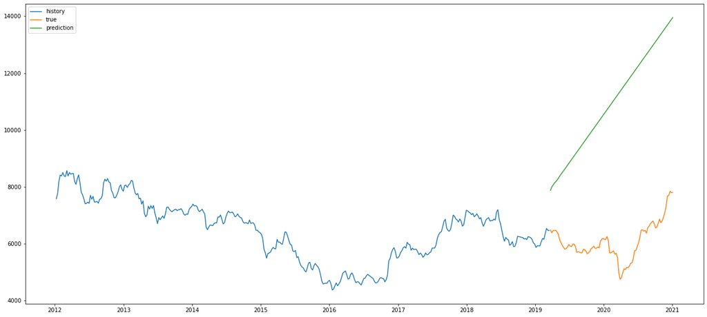

```python
# Plot of forecast vs. history and true

df_fc_auto = pd.DataFrame(fc_auto,index = test.index,columns=['Prediction'])

plt.plot(train, label='history')
plt.plot(test, label='true')
plt.plot(df_fc_auto, label='prediction')

plt.legend()
plt.show()
```

```python
# Accuracy metrics

forecast_metrics(fc_auto, test.values)
```

```
MAPE: 0.805360
ME: 4847.365058
MAE: 4847.365058
MPE: 0.805360
RMSE: 5102.366909
```

**Gesamtbewertung**:

### Modeling: Multivariate Zeitreihen mit SARIMAX

Im Vergleich zu univariaten Zeitreihen haben multivariate Zeitreihen mehr als eine zeitabhängige Variable. Jede Variable hängt nicht nur von ihren vergangenen Werten ab, sondern hat auch eine gewisse Abhängigkeit zu anderen Variablen.

Die Vorgehensweise zur Definition eines Modells in Python ist dabei nahezu identisch wie bei der univariaten Zeitreihe. Die einzige Veränderung ist die Einbeziehung der Features ("exog"), sodass sich das SARIMAX-Modell ergibt.

```python
# Set date as index

df_input_output = df_input_output.set_index('date')
df_input_output.head()
```

| date | id | lme_copper_cash__cwt_coefficients__coeff_10__w_5__widths_(2, 5, 10, 20) | lme_copper_cash__cwt_coefficients__coeff_9__w_5__widths_(2, 5, 10, 20) | lme_copper_cash__cwt_coefficients__coeff_10__w_10__widths_(2, 5, 10, 20) | lme_copper_cash__cwt_coefficients__coeff_9__w_2__widths_(2, 5, 10, 20) | lme_copper_cash__cwt_coefficients__coeff_10__w_20__widths_(2, 5, 10, 20) | lme_copper_cash__cwt_coefficients__coeff_8__w_5__widths_(2, 5, 10, 20) | lme_copper_cash__cwt_coefficients__coeff_9__w_10__widths_(2, 5, 10, 20) | lme_copper_cash__cwt_coefficients__coeff_9__w_20__widths_(2, 5, 10, 20) | lme_copper_cash__cwt_coefficients__coeff_8__w_10__widths_(2, 5, 10, 20) | ... | lme_copper_stock__spkt_welch_density__coeff_2 | lme_copper_cash__permutation_entropy__dimension_6__tau_1 | lme_copper_stock__energy_ratio_by_chunks__num_segments_10__segment_focus_8 | lme_copper_cash__energy_ratio_by_chunks__num_segments_10__segment_focus_8 | lme_copper_stock__autocorrelation__lag_7 | lme_copper_cash__change_quantiles__f_agg_"var"__isabs_True__qh_0.8__ql_0.0 | lme_copper_stock__cwt_coefficients__coeff_4__w_5__widths_(2, 5, 10, 20) | lme_copper_stock__approximate_entropy__m_2__r_0.7 | lme_copper_stock__agg_linear_trend__attr_"rvalue"__chunk_len_10__f_agg_"mean" | lme_copper_cash |
| --- | --- | --- | --- | --- | --- | --- | --- | --- | --- | --- | --- | --- | --- | --- | --- | --- | --- | --- | --- | --- | --- |
| 2012-01-08 | 1 | 8602.117939 | 10935.500183 | 9020.109055 | 5011.405561 | 7080.385602 | 12767.469234 | 10704.946656 | 8287.179311 | 12320.592967 | ... | 3.599714e+08 | 1.791759 | 0.0 | 0.0 | -0.873027 | 0.000000 | 600683.121935 | 0.000000 | -1.0 | 7574.75 |
| 2012-01-15 | 1 | 8602.117939 | 10935.500183 | 9020.109055 | 5011.405561 | 7080.385602 | 12767.469234 | 10704.946656 | 8287.179311 | 12320.592967 | ... | 3.599714e+08 | 1.791759 | 0.0 | 0.0 | -0.873027 | 0.000000 | 600683.121935 | 0.000000 | -1.0 | 7749.00 |
| 2012-01-22 | 1 | 8602.117939 | 10935.500183 | 9020.109055 | 5011.405561 | 7080.385602 | 12767.469234 | 10704.946656 | 8287.179311 | 12320.592967 | ... | 3.599714e+08 | 1.791759 | 0.0 | 0.0 | -0.873027 | 0.000000 | 600683.121935 | 0.000000 | -1.0 | 8188.60 |
| 2012-01-29 | 1 | 8602.117939 | 10935.500183 | 9020.109055 | 5011.405561 | 7080.385602 | 12767.469234 | 10704.946656 | 8287.179311 | 12320.592967 | ... | 4.510042e+05 | 1.791759 | 0.0 | 0.0 | -0.873027 | 17602.655625 | 600683.121935 | 0.405465 | -1.0 | 8408.20 |
| 2012-02-05 | 1 | 8602.117939 | 10935.500183 | 9020.109055 | 5011.405561 | 7080.385602 | 12767.469234 | 10704.946656 | 8287.179311 | 12320.592967 | ... | 1.361986e+07 | 1.791759 | 0.0 | 0.0 | -0.873027 | 17602.655625 | 357920.129377 | 0.287682 | -1.0 | 8379.00 |

5 rows × 233 columns

```python
df_mul_arima = df_input_output.copy()
```

```python
# Check if stationary

for col in df_mul_arima.columns:
    result = adfuller(df_mul_arima[col])

    print(col+': ')
    print('ADF Statistic: %f' % result[0])
    print('p-value: %f' % result[1])
    print('Critical Values:')
    for key, value in result[4].items():
        print('\t%s: %.3f' % (key, value))
    print(' ')
```

```
id:
ADF Statistic: nan
p-value: nan
Critical Values:
	1%: -3.444
	5%: -2.868
	10%: -2.570

lme_copper_cash__cwt_coefficients__coeff_10__w_5__widths_(2, 5, 10, 20):
ADF Statistic: -1.807078
p-value: 0.376953
Critical Values:
	1%: -3.445
	5%: -2.868
	10%: -2.570

lme_copper_cash__cwt_coefficients__coeff_9__w_5__widths_(2, 5, 10, 20):
ADF Statistic: -3.414161
p-value: 0.010485
Critical Values:
	1%: -3.445
	5%: -2.868
	10%: -2.570

lme_copper_cash__cwt_coefficients__coeff_10__w_10__widths_(2, 5, 10, 20):
ADF Statistic: -1.430218
p-value: 0.567706
Critical Values:
	1%: -3.445
	5%: -2.868
	10%: -2.570

lme_copper_cash__cwt_coefficients__coeff_9__w_2__widths_(2, 5, 10, 20):
ADF Statistic: -2.118530
p-value: 0.237129
Critical Values:
	1%: -3.445
	5%: -2.868
	10%: -2.570

```

[output cut: 8 more lines]

```
lme_copper_cash__cwt_coefficients__coeff_8__w_5__widths_(2, 5, 10, 20):
ADF Statistic: -1.682934
p-value: 0.439926
Critical Values:
	1%: -3.445
	5%: -2.868
	10%: -2.570

lme_copper_cash__cwt_coefficients__coeff_9__w_10__widths_(2, 5, 10, 20):
ADF Statistic: -2.055278
p-value: 0.262873
Critical Values:
	1%: -3.445
	5%: -2.868
	10%: -2.570
```

```
lme_copper_cash__cwt_coefficients__coeff_9__w_20__widths_(2, 5, 10, 20):
ADF Statistic: -2.057972
p-value: 0.261747
Critical Values:
	1%: -3.445
	5%: -2.868
	10%: -2.570

lme_copper_cash__cwt_coefficients__coeff_8__w_10__widths_(2, 5, 10, 20):
ADF Statistic: -2.115728
p-value: 0.238238
Critical Values:
	1%: -3.445
	5%: -2.868
	10%: -2.570

lme_copper_cash__cwt_coefficients__coeff_7__w_5__widths_(2, 5, 10, 20):
ADF Statistic: -1.812727
p-value: 0.374162
Critical Values:
	1%: -3.445
	5%: -2.868
	10%: -2.570

lme_copper_cash__minimum:
ADF Statistic: -1.816639
p-value: 0.372233
Critical Values:
	1%: -3.444
	5%: -2.868
	10%: -2.570

lme_copper_cash__mean:
ADF Statistic: -2.176985
p-value: 0.214704
Critical Values:
	1%: -3.445
	5%: -2.868
	10%: -2.570

```

[output cut: 680 more lines]

```
lme_copper_stock__cwt_coefficients__coeff_0__w_2__widths_(2, 5, 10, 20):
ADF Statistic: -3.052002
p-value: 0.030315
Critical Values:
	1%: -3.445
	5%: -2.868
	10%: -2.570

lme_copper_stock__change_quantiles__f_agg_"var"__isabs_False__qh_1.0__ql_0.0:
ADF Statistic: -2.280260
p-value: 0.178414
Critical Values:
	1%: -3.445
	5%: -2.868
	10%: -2.570
```

```
lme_copper_stock__cwt_coefficients__coeff_1__w_2__widths_(2, 5, 10, 20):
ADF Statistic: -3.353296
p-value: 0.012658
Critical Values:
	1%: -3.445
	5%: -2.868
	10%: -2.570

lme_copper_cash__linear_trend__attr_"slope":
ADF Statistic: -4.171366
p-value: 0.000736
Critical Values:
	1%: -3.445
	5%: -2.868
	10%: -2.570

lme_copper_stock__permutation_entropy__dimension_5__tau_1:
ADF Statistic: -5.586822
p-value: 0.000001
Critical Values:
	1%: -3.445
	5%: -2.868
	10%: -2.570

lme_copper_cash__change_quantiles__f_agg_"mean"__isabs_False__qh_0.8__ql_0.0:
ADF Statistic: -7.916966
p-value: 0.000000
Critical Values:
	1%: -3.444
	5%: -2.868
	10%: -2.570

lme_copper_stock__change_quantiles__f_agg_"var"__isabs_False__qh_1.0__ql_0.6:
ADF Statistic: -6.833178
p-value: 0.000000
Critical Values:
	1%: -3.444
	5%: -2.868
	10%: -2.570

```

[output cut: 1008 more lines]

```
lme_copper_stock__agg_linear_trend__attr_"rvalue"__chunk_len_10__f_agg_"mean":
ADF Statistic: -6.059839
p-value: 0.000000
Critical Values:
	1%: -3.444
	5%: -2.868
	10%: -2.570

lme_copper_cash:
ADF Statistic: -1.897082
p-value: 0.333435
Critical Values:
	1%: -3.444
	5%: -2.868
	10%: -2.570
```

**Interpretation**:

Der Check hinsichtlich Stationarität zeigt, dass sehr viele Features nicht-stationär sind (p-value > 0.05).

Daher wird im Folgenden eine erste Differenzierung durchgeführt.

```python
# Differencing of series to transform non-stationary to stationary (d parameter)

df_mul_arima_diff = df_mul_arima.diff().dropna()

for col in df_mul_arima_diff.columns:
    result = adfuller(df_mul_arima_diff[col])

    print(col+': ')
    print('ADF Statistic: %f' % result[0])
    print('p-value: %f' % result[1])
    print('Critical Values:')
    for key, value in result[4].items():
        print('\t%s: %.3f' % (key, value))
    print(' ')
```

```
id:
ADF Statistic: nan
p-value: nan
Critical Values:
	1%: -3.444
	5%: -2.868
	10%: -2.570

lme_copper_cash__cwt_coefficients__coeff_10__w_5__widths_(2, 5, 10, 20):
ADF Statistic: -7.102538
p-value: 0.000000
Critical Values:
	1%: -3.445
	5%: -2.868
	10%: -2.570

lme_copper_cash__cwt_coefficients__coeff_9__w_5__widths_(2, 5, 10, 20):
ADF Statistic: -12.343200
p-value: 0.000000
Critical Values:
	1%: -3.445
	5%: -2.868
	10%: -2.570

lme_copper_cash__cwt_coefficients__coeff_10__w_10__widths_(2, 5, 10, 20):
ADF Statistic: -5.136561
p-value: 0.000012
Critical Values:
	1%: -3.445
	5%: -2.868
	10%: -2.570
```

```
lme_copper_cash__cwt_coefficients__coeff_9__w_2__widths_(2, 5, 10, 20):
ADF Statistic: -9.609474
p-value: 0.000000
Critical Values:
	1%: -3.445
	5%: -2.868
	10%: -2.570

lme_copper_cash__cwt_coefficients__coeff_10__w_20__widths_(2, 5, 10, 20):
ADF Statistic: -5.259218
p-value: 0.000007
Critical Values:
	1%: -3.445
	5%: -2.868
	10%: -2.570

lme_copper_cash__cwt_coefficients__coeff_8__w_5__widths_(2, 5, 10, 20):
ADF Statistic: -14.398983
p-value: 0.000000
Critical Values:
	1%: -3.445
	5%: -2.868
	10%: -2.570

lme_copper_cash__cwt_coefficients__coeff_9__w_10__widths_(2, 5, 10, 20):
ADF Statistic: -4.852896
p-value: 0.000043
Critical Values:
	1%: -3.445
	5%: -2.868
	10%: -2.570

lme_copper_cash__cwt_coefficients__coeff_9__w_20__widths_(2, 5, 10, 20):
ADF Statistic: -4.921187
p-value: 0.000032
Critical Values:
	1%: -3.445
	5%: -2.868
	10%: -2.570

```

[output cut: 720 more lines]

```
lme_copper_stock__change_quantiles__f_agg_"var"__isabs_False__qh_1.0__ql_0.0:
ADF Statistic: -9.363795
p-value: 0.000000
Critical Values:
	1%: -3.445
	5%: -2.868
	10%: -2.570

lme_copper_stock__cwt_coefficients__coeff_1__w_2__widths_(2, 5, 10, 20):
ADF Statistic: -8.875122
p-value: 0.000000
Critical Values:
	1%: -3.445
	5%: -2.868
	10%: -2.570
```

```
lme_copper_cash__linear_trend__attr_"slope":
ADF Statistic: -9.917235
p-value: 0.000000
Critical Values:
	1%: -3.445
	5%: -2.868
	10%: -2.570

lme_copper_stock__permutation_entropy__dimension_5__tau_1:
ADF Statistic: -10.971797
p-value: 0.000000
Critical Values:
	1%: -3.445
	5%: -2.868
	10%: -2.570

lme_copper_cash__change_quantiles__f_agg_"mean"__isabs_False__qh_0.8__ql_0.0:
ADF Statistic: -8.703069
p-value: 0.000000
Critical Values:
	1%: -3.445
	5%: -2.868
	10%: -2.570

lme_copper_stock__change_quantiles__f_agg_"var"__isabs_False__qh_1.0__ql_0.6:
ADF Statistic: -12.766814
p-value: 0.000000
Critical Values:
	1%: -3.445
	5%: -2.868
	10%: -2.570

lme_copper_cash__cid_ce__normalize_False:
ADF Statistic: -8.480857
p-value: 0.000000
Critical Values:
	1%: -3.445
	5%: -2.868
	10%: -2.570

```

[output cut: 1000 more lines]

```
lme_copper_stock__agg_linear_trend__attr_"rvalue"__chunk_len_10__f_agg_"mean":
ADF Statistic: -11.201254
p-value: 0.000000
Critical Values:
	1%: -3.445
	5%: -2.868
	10%: -2.570

lme_copper_cash:
ADF Statistic: -16.358392
p-value: 0.000000
Critical Values:
	1%: -3.444
	5%: -2.868
	10%: -2.570
```

**Interpretation**:

Nach der 1. Differenzierung sind alle Features bereits stationär und können nun weiterverarbeitet werden.

```python
# Split data into train and test

size = int(len(df_mul_arima) * 0.8)

train_mul, test_mul = df_mul_arima[0:size], df_mul_arima[size:len(df_mul_arima)]
```

```python
# Check size of train and test

print(train_mul.shape)
print(test_mul.shape)
```

```
(376, 233)
(94, 233)
```

```python
# Build first model with order = 1,1,1

from statsmodels.tsa.arima.model import ARIMA

model = ARIMA(train_mul.lme_copper_cash, order=(1, 1, 1),exog=train_mul.iloc[:,:-1])


model_fit = model.fit()

print(model_fit.summary())
```

```
                               SARIMAX Results
==============================================================================
Dep. Variable:        lme_copper_cash   No. Observations:                  376
Model:                 ARIMA(1, 1, 1)   Log Likelihood                -767.409
Date:                Sun, 01 May 2022   AIC                           2004.818
Time:                        20:36:15   BIC                           2927.645
Sample:                    01-08-2012   HQIC                          2371.185
                         - 03-17-2019
Covariance Type:                  opg
===================================================================================================================================================
                                                                                      coef    std err          z      P>|z|      [0.025      0.975]
---------------------------------------------------------------------------------------------------------------------------------------------------
id                                                                                  0.0001   1.33e-18    9.5e+13      0.000       0.000       0.000
lme_copper_cash__cwt_coefficients__coeff_10__w_5__widths_(2, 5, 10, 20)             0.0006   2.14e-17   2.78e+13      0.000       0.001       0.001
lme_copper_cash__cwt_coefficients__coeff_9__w_5__widths_(2, 5, 10, 20)              0.0088        nan        nan        nan         nan         nan
lme_copper_cash__cwt_coefficients__coeff_10__w_10__widths_(2, 5, 10, 20)           -0.0493   2.63e-17  -1.87e+15      0.000      -0.049      -0.049
lme_copper_cash__cwt_coefficients__coeff_9__w_2__widths_(2, 5, 10, 20)             -0.0009   4.93e-17  -1.76e+13      0.000      -0.001      -0.001
lme_copper_cash__cwt_coefficients__coeff_10__w_20__widths_(2, 5, 10, 20)           -0.0464   1.88e-17  -2.46e+15      0.000      -0.046      -0.046
lme_copper_cash__cwt_coefficients__coeff_8__w_5__widths_(2, 5, 10, 20)             -0.0025   1.89e-17  -1.34e+14      0.000      -0.003      -0.003
lme_copper_cash__cwt_coefficients__coeff_9__w_10__widths_(2, 5, 10, 20)             0.0256   1.63e-17   1.57e+15      0.000       0.026       0.026
lme_copper_cash__cwt_coefficients__coeff_9__w_20__widths_(2, 5, 10, 20)             0.0235   1.11e-17   2.11e+15      0.000       0.023       0.023
lme_copper_cash__cwt_coefficients__coeff_8__w_10__widths_(2, 5, 10, 20)            -0.0819    2.3e-17  -3.56e+15      0.000      -0.082      -0.082
lme_copper_cash__cwt_coefficients__coeff_7__w_5__widths_(2, 5, 10, 20)              0.0070   1.52e-17   4.63e+14      0.000       0.007       0.007
lme_copper_cash__minimum                                                            0.0317   8.09e-18   3.92e+15      0.000       0.032       0.032
lme_copper_cash__mean                                                               0.0243   5.86e-18   4.15e+15      0.000       0.024       0.024
lme_copper_cash__root_mean_square                                                   0.0240   6.25e-18   3.85e+15      0.000       0.024       0.024
lme_copper_cash__cwt_coefficients__coeff_8__w_20__widths_(2, 5, 10, 20)            -0.0804   1.91e-17  -4.21e+15      0.000      -0.080      -0.080
lme_copper_cash__absolute_maximum                                                   0.0130   4.47e-17   2.91e+14      0.000       0.013       0.013
lme_copper_cash__maximum                                                            0.0130   4.47e-17   2.91e+14      0.000       0.013       0.013
lme_copper_cash__cwt_coefficients__coeff_8__w_2__widths_(2, 5, 10, 20)              0.0162   1.94e-17   8.36e+14      0.000       0.016       0.016
lme_copper_cash__quantile__q_0.1                                                    0.0199   3.15e-17    6.3e+14      0.000       0.020       0.020
lme_copper_cash__quantile__q_0.2                                                    0.0268   2.13e-17   1.25e+15      0.000       0.027       0.027
lme_copper_cash__quantile__q_0.8                                                    0.0300   1.64e-17   1.83e+15      0.000       0.030       0.030
lme_copper_cash__quantile__q_0.9                                                    0.0145   4.94e-17   2.93e+14      0.000       0.014       0.014
lme_copper_cash__quantile__q_0.7                                                    0.0265   9.63e-18   2.75e+15      0.000       0.027       0.027
lme_copper_cash__quantile__q_0.3                                                    0.0315   7.49e-17   4.21e+14      0.000       0.031       0.031
lme_copper_cash__quantile__q_0.6                                                    0.0286   2.33e-17   1.23e+15      0.000       0.029       0.029
lme_copper_cash__quantile__q_0.4                                                    0.0262   1.32e-17   1.99e+15      0.000       0.026       0.026
lme_copper_cash__median                                                             0.0187   3.97e-17   4.71e+14      0.000       0.019       0.019
lme_copper_cash__cwt_coefficients__coeff_7__w_10__widths_(2, 5, 10, 20)             0.0420   3.42e-17   1.23e+15      0.000       0.042       0.042
```

[output cut: 202 more lines]

```
lme_copper_stock__approximate_entropy__m_2__r_0.7                                  -0.0002   1.71e-20  -1.02e+16      0.000      -0.000      -0.000
lme_copper_stock__agg_linear_trend__attr_"rvalue"__chunk_len_10__f_agg_"mean"       0.0004   6.12e-19   6.19e+14      0.000       0.000       0.000
ar.L1                                                                               0.2127   7.19e-19   2.96e+17      0.000       0.213       0.213
ma.L1                                                                              -0.3607   6.01e-19     -6e+17      0.000      -0.361      -0.361
sigma2                                                                              3.5565   7.36e-20   4.83e+19      0.000       3.556       3.556
===================================================================================
Ljung-Box (L1) (Q):                   0.02   Jarque-Bera (JB):                 0.62
Prob(Q):                              0.90   Prob(JB):                         0.73
Heteroskedasticity (H):               1.39   Skew:                             0.08
Prob(H) (two-sided):                  0.06   Kurtosis:                         3.12
===================================================================================

Warnings:
[1] Covariance matrix calculated using the outer product of gradients (complex-step).
[2] Covariance matrix is singular or near-singular, with condition number 1.09e+47. Standard errors may be unstable.
```

**Interpretation / Bewertung**:

Nahezu alle Features weisen einen p-values < 0.05 auf, wodurch eine statistische Signifikanz unterstellt werden kann. Ausnahme bilden drei Features, die darüber liegen:

- lme_copper_stock**change_quantiles**f*agg*"var"_isabs_True**qh_1.0**ql_0.2
- lme_copper_stock**time_reversal_asymmetry_statistic**lag_1
- lme_copper_stock**spkt_welch_density**coeff_2

Daher soll im Folgenden noch ein weiteres Modell mit einem Autoregressiv-Wert p von 2 aufgebaut werden.

```python
# Build first model with order = 2,1,1

from statsmodels.tsa.arima.model import ARIMA

model_2 = ARIMA(train_mul.lme_copper_cash, order=(2, 1, 1),exog=train_mul.iloc[:,:-1])


model_fit_2 = model_2.fit(method='statespace')

print(model_fit_2.summary())
```

```
                               SARIMAX Results
==============================================================================
Dep. Variable:        lme_copper_cash   No. Observations:                  376
Model:                 ARIMA(2, 1, 1)   Log Likelihood                -765.766
Date:                Sun, 01 May 2022   AIC                           2003.532
Time:                        20:36:21   BIC                           2930.286
Sample:                    01-08-2012   HQIC                          2371.458
                         - 03-17-2019
Covariance Type:                  opg
===================================================================================================================================================
                                                                                      coef    std err          z      P>|z|      [0.025      0.975]
---------------------------------------------------------------------------------------------------------------------------------------------------
id                                                                                  0.0001   1.02e-19   1.24e+15      0.000       0.000       0.000
lme_copper_cash__cwt_coefficients__coeff_10__w_5__widths_(2, 5, 10, 20)             0.0006      6e-18   9.93e+13      0.000       0.001       0.001
lme_copper_cash__cwt_coefficients__coeff_9__w_5__widths_(2, 5, 10, 20)              0.0088        nan        nan        nan         nan         nan
lme_copper_cash__cwt_coefficients__coeff_10__w_10__widths_(2, 5, 10, 20)           -0.0493   1.58e-18  -3.12e+16      0.000      -0.049      -0.049
lme_copper_cash__cwt_coefficients__coeff_9__w_2__widths_(2, 5, 10, 20)             -0.0009   2.72e-17  -3.19e+13      0.000      -0.001      -0.001
lme_copper_cash__cwt_coefficients__coeff_10__w_20__widths_(2, 5, 10, 20)           -0.0464   2.28e-18  -2.03e+16      0.000      -0.046      -0.046
lme_copper_cash__cwt_coefficients__coeff_8__w_5__widths_(2, 5, 10, 20)             -0.0025   1.44e-18  -1.76e+15      0.000      -0.003      -0.003
lme_copper_cash__cwt_coefficients__coeff_9__w_10__widths_(2, 5, 10, 20)             0.0256   4.89e-18   5.24e+15      0.000       0.026       0.026
lme_copper_cash__cwt_coefficients__coeff_9__w_20__widths_(2, 5, 10, 20)             0.0235   5.83e-18   4.03e+15      0.000       0.023       0.023
lme_copper_cash__cwt_coefficients__coeff_8__w_10__widths_(2, 5, 10, 20)            -0.0819   8.72e-18   -9.4e+15      0.000      -0.082      -0.082
lme_copper_cash__cwt_coefficients__coeff_7__w_5__widths_(2, 5, 10, 20)              0.0070   1.36e-17   5.17e+14      0.000       0.007       0.007
lme_copper_cash__minimum                                                            0.0317   2.39e-18   1.33e+16      0.000       0.032       0.032
lme_copper_cash__mean                                                               0.0243   2.02e-18   1.21e+16      0.000       0.024       0.024
lme_copper_cash__root_mean_square                                                   0.0240   2.16e-18   1.11e+16      0.000       0.024       0.024
lme_copper_cash__cwt_coefficients__coeff_8__w_20__widths_(2, 5, 10, 20)            -0.0804    8.2e-18   -9.8e+15      0.000      -0.080      -0.080
lme_copper_cash__absolute_maximum                                                   0.0130   3.98e-18   3.28e+15      0.000       0.013       0.013
lme_copper_cash__maximum                                                            0.0130   3.98e-18   3.28e+15      0.000       0.013       0.013
lme_copper_cash__cwt_coefficients__coeff_8__w_2__widths_(2, 5, 10, 20)              0.0162   1.95e-17   8.31e+14      0.000       0.016       0.016
lme_copper_cash__quantile__q_0.1                                                    0.0199   2.35e-18   8.44e+15      0.000       0.020       0.020
lme_copper_cash__quantile__q_0.2                                                    0.0268   3.84e-18   6.98e+15      0.000       0.027       0.027
lme_copper_cash__quantile__q_0.8                                                    0.0300   9.82e-18   3.06e+15      0.000       0.030       0.030
lme_copper_cash__quantile__q_0.9                                                    0.0145   2.43e-18   5.95e+15      0.000       0.014       0.014
lme_copper_cash__quantile__q_0.7                                                    0.0265   7.02e-18   3.78e+15      0.000       0.027       0.027
lme_copper_cash__quantile__q_0.3                                                    0.0315   5.28e-18   5.97e+15      0.000       0.031       0.031
lme_copper_cash__quantile__q_0.6                                                    0.0286   1.17e-17   2.44e+15      0.000       0.029       0.029
lme_copper_cash__quantile__q_0.4                                                    0.0262   1.67e-17   1.57e+15      0.000       0.026       0.026
lme_copper_cash__median                                                             0.0187   1.53e-18   1.22e+16      0.000       0.019       0.019
lme_copper_cash__cwt_coefficients__coeff_7__w_10__widths_(2, 5, 10, 20)             0.0420   2.45e-17   1.71e+15      0.000       0.042       0.042
```

[output cut: 203 more lines]

```
lme_copper_stock__agg_linear_trend__attr_"rvalue"__chunk_len_10__f_agg_"mean"       0.0004   2.97e-19   1.28e+15      0.000       0.000       0.000
ar.L1                                                                              -0.4406   2.35e-19  -1.88e+18      0.000      -0.441      -0.441
ar.L2                                                                              -0.1703   8.58e-19  -1.98e+17      0.000      -0.170      -0.170
ma.L1                                                                               0.2924   1.55e-19   1.88e+18      0.000       0.292       0.292
sigma2                                                                              3.5049   3.32e-20   1.06e+20      0.000       3.505       3.505
===================================================================================
Ljung-Box (L1) (Q):                   0.00   Jarque-Bera (JB):                 2.34
Prob(Q):                              0.99   Prob(JB):                         0.31
Heteroskedasticity (H):               1.38   Skew:                             0.17
Prob(H) (two-sided):                  0.07   Kurtosis:                         3.18
===================================================================================

Warnings:
[1] Covariance matrix calculated using the outer product of gradients (complex-step).
[2] Covariance matrix is singular or near-singular, with condition number 1.07e+46. Standard errors may be unstable.
```

**Interpretation / Bewertung**:

Zwar sind auch nach der 2. Differenzierung noch Features mit einem p-value > 0.05 zu finden (z.B. lme_copper_stock**spkt_welch_density**coeeff_2), was wohl aber aufgrund der großen Anzahl der einzubeziehenden Features nicht ganz auszuschließen ist.

Es wird im Folgenden daher auf eine weitere Differenzierung verzichtet und versucht, das Modell trotzdem auf die Testdaten zu fitten.

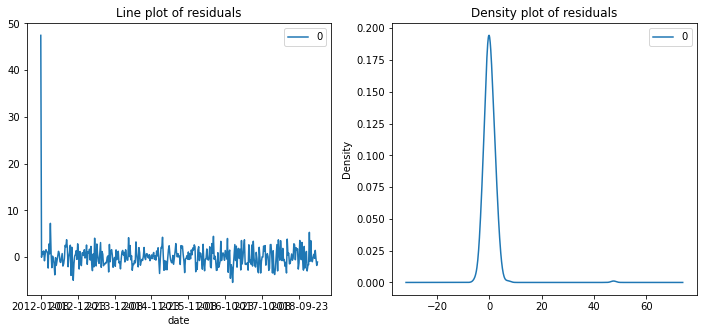

```python
# residual plots

residuals = pd.DataFrame(model_fit_2.resid)
fig, ax = plt.subplots(1,2,figsize=(12,5))

residuals.plot(title="Line plot of residuals", ax=ax[0])
residuals.plot(kind='kde', title='Density plot of residuals', ax=ax[1])
plt.show()
```

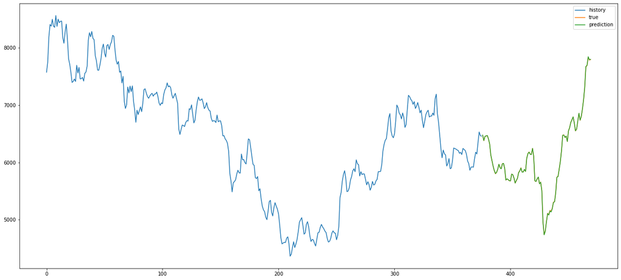

```python
# Fit auf den Testdaten und Darstellung der gesamten Zeitreihe inkl. Vorhersage

fc = model_fit_2.forecast(94, alpha=0.05,exog=test_mul.iloc[:,:-1])

fc_df = pd.DataFrame(fc, index=test_mul.index)


plt.plot(np.arange(0, len(train_mul)), train_mul.lme_copper_cash, label='history')
plt.plot(np.arange(len(train_mul), len(train_mul) + len(test_mul)), test_mul.lme_copper_cash, label='true')
plt.plot(np.arange(len(train_mul), len(train_mul) + len(test_mul)), fc_df.predicted_mean, label='prediction')

plt.legend()
plt.show()
```

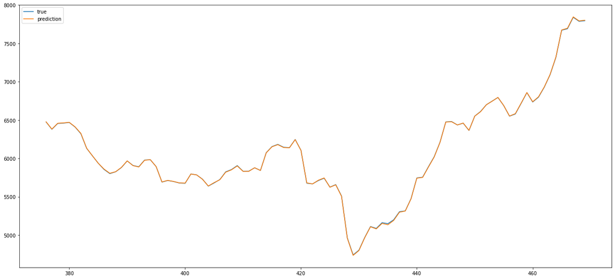

```python
# Plot performance on test data

plt.plot(np.arange(len(train_mul), len(train_mul) + len(test_mul)), test_mul.lme_copper_cash, label='true')
plt.plot(np.arange(len(train_mul), len(train_mul) + len(test_mul)), fc_df.predicted_mean, label='prediction')

plt.legend()
plt.show()
```

```python
# Accuracy metrics

def forecast_metrics (forecast, test):
    mape = np.mean(np.abs(forecast - test)/np.abs(test))
    me = np.mean(forecast - test)
    mae = np.mean(np.abs(forecast - test))
    mpe = np.mean((forecast - test)/test)
    rmse = np.mean((forecast - test)**2)**.5

    print('MAPE: %f' % mape)
    print('ME: %f' % me)
    print('MAE: %f' % mae)
    print('MPE: %f' % mpe)
    print('RMSE: %f' % rmse)

forecast_metrics(fc, test_mul['lme_copper_cash'].values)
```

```
MAPE: 0.000529
ME: -0.302370
MAE: 3.139232
MPE: -0.000093
RMSE: 3.868952
```

**Fazit**:

Insgesamt performt das multivariate Modell deutlich besser, wie auch die Metriken oben klar zeigen. So konnte der MAPE auf nahezu 0 reduziert werden, wodurch das Modell bei der Prognose der kommenden 94 Wochen fast zu 100% richtig liegt.

Es stellt sich bei den sehr guten Werten jedoch ganz klar die Frage eines Overfittings, da die ja doch stark volatilen Verläufe des Kupferpreises nahezu perfekt getroffen werden.

Zu beachten gilt jedoch, dass in diesem Fall keine Cross Validation durchgeführt wurde, mit der das Overfitting-Problem reduziert werden könnte. Dies soll im Folgenden nun noch durchgeführt werden.

```python
# Cross-validation mit TimeSeriesSplit

from sklearn.model_selection import TimeSeriesSplit

tscv = TimeSeriesSplit(n_splits = 3)

i=0
for train, test in tscv.split(df_mul_arima):
    i=i+1
    print ("No of observations under train%s=%s" % (i, len(train)))
    print ("No of observations under test%s=%s" % (i, len(test)))
```

```
No of observations under train1=119
No of observations under test1=117
No of observations under train2=236
No of observations under test2=117
No of observations under train3=353
No of observations under test3=117
```

```python
# Train-Test Split gemäß des Cross-Time-Series-Split

train1, test1 = pd.DataFrame(df_mul_arima.iloc[:119, :]), df_mul_arima.iloc[119:236, :]
train2, test2 = df_mul_arima.iloc[:236, :], df_mul_arima.iloc[236:353, :]
train3, test3 = df_mul_arima.iloc[:353, :], df_mul_arima.iloc[353:, :]
```

```python
test1.head()
```

| date | id | lme_copper_cash__cwt_coefficients__coeff_10__w_5__widths_(2, 5, 10, 20) | lme_copper_cash__cwt_coefficients__coeff_9__w_5__widths_(2, 5, 10, 20) | lme_copper_cash__cwt_coefficients__coeff_10__w_10__widths_(2, 5, 10, 20) | lme_copper_cash__cwt_coefficients__coeff_9__w_2__widths_(2, 5, 10, 20) | lme_copper_cash__cwt_coefficients__coeff_10__w_20__widths_(2, 5, 10, 20) | lme_copper_cash__cwt_coefficients__coeff_8__w_5__widths_(2, 5, 10, 20) | lme_copper_cash__cwt_coefficients__coeff_9__w_10__widths_(2, 5, 10, 20) | lme_copper_cash__cwt_coefficients__coeff_9__w_20__widths_(2, 5, 10, 20) | lme_copper_cash__cwt_coefficients__coeff_8__w_10__widths_(2, 5, 10, 20) | ... | lme_copper_stock__spkt_welch_density__coeff_2 | lme_copper_cash__permutation_entropy__dimension_6__tau_1 | lme_copper_stock__energy_ratio_by_chunks__num_segments_10__segment_focus_8 | lme_copper_cash__energy_ratio_by_chunks__num_segments_10__segment_focus_8 | lme_copper_stock__autocorrelation__lag_7 | lme_copper_cash__change_quantiles__f_agg_"var"__isabs_True__qh_0.8__ql_0.0 | lme_copper_stock__cwt_coefficients__coeff_4__w_5__widths_(2, 5, 10, 20) | lme_copper_stock__approximate_entropy__m_2__r_0.7 | lme_copper_stock__agg_linear_trend__attr_"rvalue"__chunk_len_10__f_agg_"mean" | lme_copper_cash |
| --- | --- | --- | --- | --- | --- | --- | --- | --- | --- | --- | --- | --- | --- | --- | --- | --- | --- | --- | --- | --- | --- |
| 2014-04-20 | 1 | 9017.099332 | 11413.966266 | 9473.136865 | 5215.747850 | 7416.441057 | 13427.478897 | 11331.347142 | 8766.981749 | 13138.871927 | ... | 1.563320e+08 | 1.791759 | 0.076720 | 0.085692 | -0.660099 | 19201.284082 | 644416.614770 | 0.156784 | -1.0 | 6626.500 |
| 2014-04-27 | 1 | 9060.625550 | 11461.627037 | 9505.280261 | 5296.009357 | 7438.711692 | 13428.364573 | 11282.635854 | 8710.486896 | 13059.889259 | ... | 1.159025e+08 | 1.791759 | 0.075378 | 0.086240 | -0.737697 | 17033.712500 | 630653.267281 | 0.102872 | -1.0 | 6697.500 |
| 2014-05-04 | 1 | 9099.713558 | 11516.686972 | 9558.827758 | 5318.133599 | 7483.047945 | 13485.529635 | 11323.316789 | 8738.863071 | 13019.333540 | ... | 2.093433e+08 | 1.791759 | 0.077414 | 0.089154 | -0.669221 | 17703.531094 | 618770.477486 | 0.166965 | -1.0 | 6729.100 |
| 2014-05-11 | 1 | 9125.449643 | 11553.229168 | 9591.961544 | 5334.175910 | 7510.280219 | 13538.491708 | 11374.979813 | 8781.851662 | 13058.214314 | ... | 2.213367e+08 | 1.791759 | 0.076748 | 0.091220 | -0.815852 | 1195.233193 | 608322.580248 | 0.159980 | -1.0 | 6722.125 |
| 2014-05-18 | 1 | 9229.159996 | 11657.757700 | 9669.084626 | 5425.823315 | 7565.405530 | 13639.962345 | 11466.437689 | 8850.793848 | 13165.592012 | ... | 7.176082e+07 | 1.791759 | 0.069553 | 0.091496 | -0.966746 | 1195.233193 | 598069.576173 | 0.162465 | -1.0 | 6938.000 |

5 rows × 233 columns

```python
# Fit der Modelle mit den vorbereiteten Trainings- und Testdatensätzen

# First Fold
model_tscv_1 = ARIMA(train1.lme_copper_cash, order=(2, 1, 1),exog=train1.iloc[:,:-1])
model_tscv_1 = model_tscv_1.fit(method='statespace')
fc_tscv_1 = model_tscv_1.forecast(117, alpha=0.05,exog=test1.iloc[:,:-1])

# Second Fold
model_tscv_2 = ARIMA(train2.lme_copper_cash, order=(2, 1, 1),exog=train2.iloc[:,:-1])
model_tscv_2 = model_tscv_2.fit(method='statespace')
fc_tscv_2 = model_tscv_2.forecast(117, alpha=0.05,exog=test2.iloc[:,:-1])

# Third Fold
model_tscv_3 = ARIMA(train3.lme_copper_cash, order=(2, 1, 1),exog=train3.iloc[:,:-1])
model_tscv_3 = model_tscv_3.fit(method='statespace')
fc_tscv_3 = model_tscv_3.forecast(117, alpha=0.05,exog=test3.iloc[:,:-1])
```

[output not shown]

```python
# Vorhersage-Metriken je Split

print('Metriken Testset 1: \n')
forecast_metrics(fc_tscv_1, test1['lme_copper_cash'].values)
print('\n')

print('Metriken Testset 2: \n')
forecast_metrics(fc_tscv_2, test2['lme_copper_cash'].values)
print('\n')

print('Metriken Testset 3: \n')
forecast_metrics(fc_tscv_3, test3['lme_copper_cash'].values)
```

```
Metriken Testset 1:

Mean absolute percentage error: 0.021854
Mean error: 108.914938
Mean absolute error: 109.010739
Mean percentage Error: 0.021840
Root Mean Squared Error: 146.004198


Metriken Testset 2:

Mean absolute percentage error: 0.002834
Mean error: 16.295867
Mean absolute error: 16.965501
Mean percentage Error: 0.002717
Root Mean Squared Error: 20.958620


Metriken Testset 3:

Mean absolute percentage error: 0.000701
Mean error: 1.169267
Mean absolute error: 4.309221
Mean percentage Error: 0.000134
Root Mean Squared Error: 5.440885
```

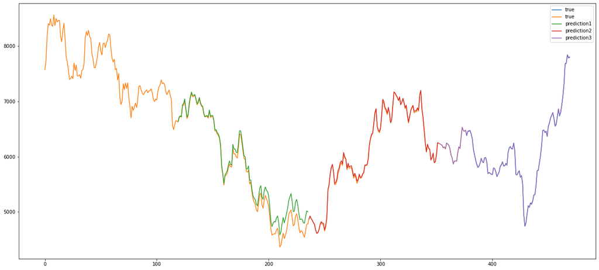

```python
# Erstellen von Dataframes je Split

fc_tscv_1_df = pd.DataFrame(fc_tscv_1, index=test1.index)
fc_tscv_2_df = pd.DataFrame(fc_tscv_2, index=test2.index)
fc_tscv_3_df = pd.DataFrame(fc_tscv_3, index=test3.index)

# Darstellung der gesamten Zeitreihe inkl. der verschiedenen Vorhersagen je Split
plt.plot(np.arange(len(train_mul), len(train_mul) + len(test_mul)), test_mul.lme_copper_cash, label='true')
plt.plot(np.arange(0, len(train_mul)), train_mul.lme_copper_cash, label='true')
plt.plot(np.arange(len(train1), len(train1) + len(test1)), fc_tscv_1_df.predicted_mean, label='prediction1')
plt.plot(np.arange(len(train2), len(train2) + len(test2)), fc_tscv_2_df.predicted_mean, label='prediction2')
plt.plot(np.arange(len(train3), len(train3) + len(test3)), fc_tscv_3_df.predicted_mean, label='prediction3')

plt.legend()
plt.show()
```

**Fazit / Interpretation**:

Mit der TimeSeries-Cross-Validation ergeben sich vor allem im ersten Split etwas stärkere Abweichungen zwischen Vorhersage und tatsächlichen Werten, sodass der MEA hier bei 109,01 US-Dollar liegt. Bei den weiteren Splits ist diese Abweichung dann erneut deutlich geringer und die Anpassung erfolgt auch hier erstaunlich gut bis nahezu perfekt.

### Modeling: Multivariate Zeitreihe mit Auto ARIMAX

Auch für die multivariate Zeitreihe soll ein Auto Arima Modell aufgebaut werden. Hierzu wird das sogenannte "Auto ARIMAX" herangezogen.

```python
import pmdarima as pm
```

```python
# training and test data

size = int(len(df_mul_arima) * 0.8)

train_mul_auto, test_mul_auto = df_mul_arima[0:size], df_mul_arima[size:len(df_mul_arima)]
```

```python
# Extract additional features as list

add_features = []

for col in train_mul_auto.columns[1:]:
    add_features.append(col)

add_features
```

```
['lme_copper_cash__cwt_coefficients__coeff_10__w_5__widths_(2, 5, 10, 20)',
 'lme_copper_cash__cwt_coefficients__coeff_9__w_5__widths_(2, 5, 10, 20)',
 'lme_copper_cash__cwt_coefficients__coeff_10__w_10__widths_(2, 5, 10, 20)',
 'lme_copper_cash__cwt_coefficients__coeff_9__w_2__widths_(2, 5, 10, 20)',
 'lme_copper_cash__cwt_coefficients__coeff_10__w_20__widths_(2, 5, 10, 20)',
 'lme_copper_cash__cwt_coefficients__coeff_8__w_5__widths_(2, 5, 10, 20)',
 'lme_copper_cash__cwt_coefficients__coeff_9__w_10__widths_(2, 5, 10, 20)',
 'lme_copper_cash__cwt_coefficients__coeff_9__w_20__widths_(2, 5, 10, 20)',
 'lme_copper_cash__cwt_coefficients__coeff_8__w_10__widths_(2, 5, 10, 20)',
 'lme_copper_cash__cwt_coefficients__coeff_7__w_5__widths_(2, 5, 10, 20)',
 'lme_copper_cash__minimum',
 'lme_copper_cash__mean',
 'lme_copper_cash__root_mean_square',
 'lme_copper_cash__cwt_coefficients__coeff_8__w_20__widths_(2, 5, 10, 20)',
 'lme_copper_cash__absolute_maximum',
 'lme_copper_cash__maximum',
 'lme_copper_cash__cwt_coefficients__coeff_8__w_2__widths_(2, 5, 10, 20)',
 'lme_copper_cash__quantile__q_0.1',
 'lme_copper_cash__quantile__q_0.2',
 'lme_copper_cash__quantile__q_0.8',
 'lme_copper_cash__quantile__q_0.9',
 'lme_copper_cash__quantile__q_0.7',
 'lme_copper_cash__quantile__q_0.3',
 'lme_copper_cash__quantile__q_0.6',
 'lme_copper_cash__quantile__q_0.4',
 'lme_copper_cash__median',
 'lme_copper_cash__cwt_coefficients__coeff_7__w_10__widths_(2, 5, 10, 20)',
 'lme_copper_cash__cwt_coefficients__coeff_7__w_20__widths_(2, 5, 10, 20)',
 'lme_copper_cash__cwt_coefficients__coeff_6__w_5__widths_(2, 5, 10, 20)',
 'lme_copper_cash__c3__lag_1',
 'lme_copper_cash__cwt_coefficients__coeff_6__w_10__widths_(2, 5, 10, 20)',
 'lme_copper_cash__mean_n_absolute_max__number_of_maxima_7',
 'lme_copper_cash__cwt_coefficients__coeff_6__w_20__widths_(2, 5, 10, 20)',
 'lme_copper_cash__c3__lag_2',
 'lme_copper_cash__cwt_coefficients__coeff_5__w_20__widths_(2, 5, 10, 20)',
 'lme_copper_cash__cwt_coefficients__coeff_5__w_10__widths_(2, 5, 10, 20)',
 'lme_copper_cash__cwt_coefficients__coeff_5__w_5__widths_(2, 5, 10, 20)',
 'lme_copper_cash__abs_energy',
 'lme_copper_cash__c3__lag_3',
 'lme_copper_cash__max_langevin_fixed_point__m_3__r_30',
```

[output cut: 177 more lines]

```
 'lme_copper_stock__agg_linear_trend__attr_"slope"__chunk_len_5__f_agg_"mean"',
 'lme_copper_stock__variation_coefficient',
 'lme_copper_stock__c3__lag_1',
 'lme_copper_stock__change_quantiles__f_agg_"var"__isabs_False__qh_0.6__ql_0.0',
 'lme_copper_cash__partial_autocorrelation__lag_1',
 'lme_copper_stock__spkt_welch_density__coeff_2',
 'lme_copper_cash__permutation_entropy__dimension_6__tau_1',
 'lme_copper_stock__energy_ratio_by_chunks__num_segments_10__segment_focus_8',
 'lme_copper_cash__energy_ratio_by_chunks__num_segments_10__segment_focus_8',
 'lme_copper_stock__autocorrelation__lag_7',
 'lme_copper_cash__change_quantiles__f_agg_"var"__isabs_True__qh_0.8__ql_0.0',
 'lme_copper_stock__cwt_coefficients__coeff_4__w_5__widths_(2, 5, 10, 20)',
 'lme_copper_stock__approximate_entropy__m_2__r_0.7',
 'lme_copper_stock__agg_linear_trend__attr_"rvalue"__chunk_len_10__f_agg_"mean"',
 'lme_copper_cash']
```

```python
# Modeling Auto Arimax

model = pm.auto_arima(train_mul_auto.lme_copper_cash, exogenous=train_mul_auto[add_features], trace=True, error_action="ignore", suppress_warnings=True)

model.fit(train_mul_auto.lme_copper_cash, exogenous=train_mul_auto[add_features])
```

```
Performing stepwise search to minimize aic
 ARIMA(2,0,2)(0,0,0)[0] intercept   : AIC=3662.042, Time=5.53 sec
 ARIMA(0,0,0)(0,0,0)[0] intercept   : AIC=3661.659, Time=4.34 sec
 ARIMA(1,0,0)(0,0,0)[0] intercept   : AIC=3663.285, Time=4.29 sec
 ARIMA(0,0,1)(0,0,0)[0] intercept   : AIC=3663.303, Time=4.81 sec
 ARIMA(0,0,0)(0,0,0)[0]             : AIC=5514.421, Time=4.12 sec
```

```
 ARIMA(1,0,1)(0,0,0)[0] intercept   : AIC=3665.677, Time=5.56 sec

Best model:  ARIMA(0,0,0)(0,0,0)[0] intercept
Total fit time: 28.679 seconds
```

```
ARIMA(order=(0, 0, 0), scoring_args={}, suppress_warnings=True)
```

```python
# Fit on test data

fc_mul_auto = model.predict(n_periods=len(test_mul_auto), exogenous=test_mul_auto[add_features])

test_mul_auto["prediction"] = fc_mul_auto
```

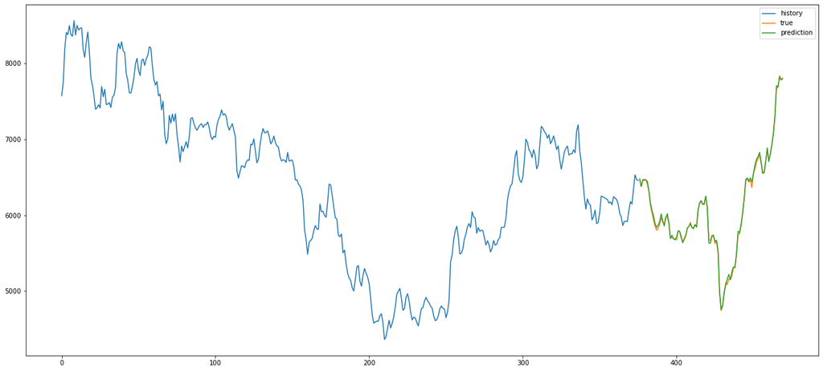

```python
# plot time series incl. prediction

plt.plot(np.arange(0, len(train_mul_auto)), train_mul_auto.lme_copper_cash, label='history')
plt.plot(np.arange(len(train_mul_auto), len(train_mul_auto) + len(test_mul_auto)), test_mul_auto.lme_copper_cash, label='true')
plt.plot(np.arange(len(train_mul_auto), len(train_mul_auto) + len(test_mul_auto)), test_mul_auto.prediction, label='prediction')

plt.legend()
plt.show()
```

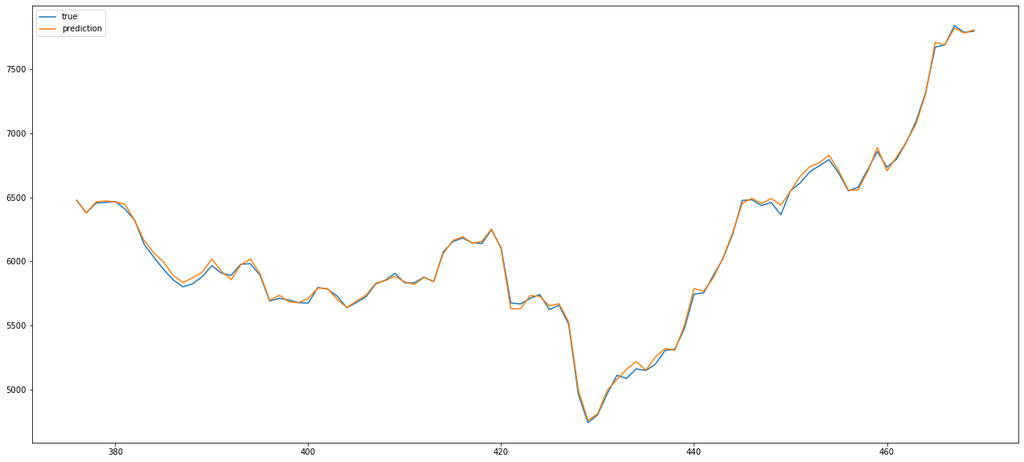

```python
# Plot performance on test data

plt.plot(np.arange(len(train_mul_auto), len(train_mul_auto) + len(test_mul_auto)), test_mul_auto.lme_copper_cash, label='true')
plt.plot(np.arange(len(train_mul_auto), len(train_mul_auto) + len(test_mul_auto)), test_mul_auto.prediction, label='prediction')

plt.legend()
plt.show()
```

```python
# Accuracy metrics

def forecast_metrics (forecast, test):
    mape = np.mean(np.abs(forecast - test)/np.abs(test))
    me = np.mean(forecast - test)
    mae = np.mean(np.abs(forecast - test))
    mpe = np.mean((forecast - test)/test)
    rmse = np.mean((forecast - test)**2)**.5

    print('MAPE: %f' % mape)
    print('ME: %f' % me)
    print('MAE: %f' % mae)
    print('MPE: %f' % mpe)
    print('RMSE: %f' % rmse)

forecast_metrics(fc_mul_auto, test_mul_auto['lme_copper_cash'].values)
```

```
MAPE: 0.003464
ME: 10.852364
MAE: 20.574848
MPE: 0.001861
RMSE: 26.426941
```

**Fazit**:

Wie die Metriken und Visualisierungen zeigen, performt das multivariate Auto-ARIMA Modell leicht schlechter als das SARIMA-Modell. Sowohl MAPE als auch RMSE haben sich etwas verschlechtert, was sich im Graph der Vorhersage im Vergleich zum tatsächlichen Wert auch zeigt.

Dennoch zeigt sich auch im Vergleich zum univariaten Auto-ARIMA Modell eine deutliche Verbesserung. Der RMSE liegt hier nur noch bei ca. 26,42 US-Dollar, wohingegen das univariate Modell noch bei 5.102 US-Dollar lag.

## CNN (Convolutional Neural Network)

Das Convolutional Neural Network ist eine besondere Form der künstlichen neuronalen Netzwerke. Es besitzt mehrere Faltungsschichten und wird vor allem für maschinelles Lernen im Bereich der Bild- und Spracherkennung eingesetzt. Dennoch kann es auch für Zeitreihenprobleme (Zeitreihenprognosen) eingesetzt werden. In diesem Fall werden dann statt räumlichen Informationen mithilfe von eindimensionalen Faltungen Informationen entlang einer Zeitdimension extrahiert.

Wie das LSTM, soll auch das CNN im Vergleich zu den bereits eingesetzten klassischen Machine-Learning Modellen für das vorliegende Zeitreihenproblem erprobt werden.

### Data Preprocessing

Ähnlich wie beim LSTM, erfordert auch das CNN ein entsprechendes Data Preprocessing.

1. Umwandlanung von Trainings- und Testdaten in Numpy-Arrays, um für CNN nutzbar zu sein
2. Normalisierung bzw. Standardisierung, um die Skalierung der Wertebereiche anzugleichen.

```python
# Normalisierung / Standardisierung

from sklearn.preprocessing import MinMaxScaler

df_input_output_scaled = df_input_output.copy()
df_input_output_scaled = df_input_output_scaled.drop('id',1)

scaler = MinMaxScaler()

df_input_output_scaled = pd.DataFrame(scaler.fit_transform(df_input_output_scaled.values),
                                      columns=df_input_output_scaled.columns, index=df_input_output_scaled.index)


# Normalisierung / Standardisierung des Labels für späteres Rescaling

df_label = pd.DataFrame(df_input_output['lme_copper_cash'])
scaler_target = MinMaxScaler()
scaler_target.fit(df_label)
```

```
MinMaxScaler()
```

```python
df_input_output_scaled.head()
```

| date | lme_copper_cash__cwt_coefficients__coeff_10__w_5__widths_(2, 5, 10, 20) | lme_copper_cash__cwt_coefficients__coeff_9__w_5__widths_(2, 5, 10, 20) | lme_copper_cash__cwt_coefficients__coeff_10__w_10__widths_(2, 5, 10, 20) | lme_copper_cash__cwt_coefficients__coeff_9__w_2__widths_(2, 5, 10, 20) | lme_copper_cash__cwt_coefficients__coeff_10__w_20__widths_(2, 5, 10, 20) | lme_copper_cash__cwt_coefficients__coeff_8__w_5__widths_(2, 5, 10, 20) | lme_copper_cash__cwt_coefficients__coeff_9__w_10__widths_(2, 5, 10, 20) | lme_copper_cash__cwt_coefficients__coeff_9__w_20__widths_(2, 5, 10, 20) | lme_copper_cash__cwt_coefficients__coeff_8__w_10__widths_(2, 5, 10, 20) | lme_copper_cash__cwt_coefficients__coeff_7__w_5__widths_(2, 5, 10, 20) | ... | lme_copper_stock__spkt_welch_density__coeff_2 | lme_copper_cash__permutation_entropy__dimension_6__tau_1 | lme_copper_stock__energy_ratio_by_chunks__num_segments_10__segment_focus_8 | lme_copper_cash__energy_ratio_by_chunks__num_segments_10__segment_focus_8 | lme_copper_stock__autocorrelation__lag_7 | lme_copper_cash__change_quantiles__f_agg_"var"__isabs_True__qh_0.8__ql_0.0 | lme_copper_stock__cwt_coefficients__coeff_4__w_5__widths_(2, 5, 10, 20) | lme_copper_stock__approximate_entropy__m_2__r_0.7 | lme_copper_stock__agg_linear_trend__attr_"rvalue"__chunk_len_10__f_agg_"mean" | lme_copper_cash |
| --- | --- | --- | --- | --- | --- | --- | --- | --- | --- | --- | --- | --- | --- | --- | --- | --- | --- | --- | --- | --- | --- |
| 2012-01-08 | 0.461798 | 0.46226 | 0.449964 | 0.485251 | 0.453256 | 0.452844 | 0.447578 | 0.451423 | 0.445696 | 0.450889 | ... | 0.030459 | 1.0 | 0.0 | 0.0 | 0.374283 | 0.00000 | 0.298057 | 0.000000 | 0.0 | 0.764392 |
| 2012-01-15 | 0.461798 | 0.46226 | 0.449964 | 0.485251 | 0.453256 | 0.452844 | 0.447578 | 0.451423 | 0.445696 | 0.450889 | ... | 0.030459 | 1.0 | 0.0 | 0.0 | 0.374283 | 0.00000 | 0.298057 | 0.000000 | 0.0 | 0.805859 |
| 2012-01-22 | 0.461798 | 0.46226 | 0.449964 | 0.485251 | 0.453256 | 0.452844 | 0.447578 | 0.451423 | 0.445696 | 0.450889 | ... | 0.030459 | 1.0 | 0.0 | 0.0 | 0.374283 | 0.00000 | 0.298057 | 0.000000 | 0.0 | 0.910473 |
| 2012-01-29 | 0.461798 | 0.46226 | 0.449964 | 0.485251 | 0.453256 | 0.452844 | 0.447578 | 0.451423 | 0.445696 | 0.450889 | ... | 0.000033 | 1.0 | 0.0 | 0.0 | 0.374283 | 0.48185 | 0.298057 | 0.689281 | 0.0 | 0.962733 |
| 2012-02-05 | 0.461798 | 0.46226 | 0.449964 | 0.485251 | 0.453256 | 0.452844 | 0.447578 | 0.451423 | 0.445696 | 0.450889 | ... | 0.001148 | 1.0 | 0.0 | 0.0 | 0.374283 | 0.48185 | 0.109508 | 0.489052 | 0.0 | 0.955784 |

5 rows × 232 columns

```python
# Split in Trainings- und Testdaten (Verhältnis 80-20)

size = int(len(df_un_arima) * 0.8)

train_cnn, test_cnn = df_input_output_scaled[0:size], df_input_output_scaled[size:len(df_input_output_scaled)]

print(len(train), len(test))
```

```
376 94
```

```python
# Extraktion von Label und Features (x, y)

x_train_cnn = train_cnn.loc[:, df_input_output_scaled.columns != 'lme_copper_cash']
y_train_cnn = train_cnn['lme_copper_cash']

x_test_cnn = test_cnn.loc[:, df_input_output_scaled.columns != 'lme_copper_cash']
y_test_cnn = test_cnn['lme_copper_cash']
```

```python
x_train_cnn
```

| date | lme_copper_cash__cwt_coefficients__coeff_10__w_5__widths_(2, 5, 10, 20) | lme_copper_cash__cwt_coefficients__coeff_9__w_5__widths_(2, 5, 10, 20) | lme_copper_cash__cwt_coefficients__coeff_10__w_10__widths_(2, 5, 10, 20) | lme_copper_cash__cwt_coefficients__coeff_9__w_2__widths_(2, 5, 10, 20) | lme_copper_cash__cwt_coefficients__coeff_10__w_20__widths_(2, 5, 10, 20) | lme_copper_cash__cwt_coefficients__coeff_8__w_5__widths_(2, 5, 10, 20) | lme_copper_cash__cwt_coefficients__coeff_9__w_10__widths_(2, 5, 10, 20) | lme_copper_cash__cwt_coefficients__coeff_9__w_20__widths_(2, 5, 10, 20) | lme_copper_cash__cwt_coefficients__coeff_8__w_10__widths_(2, 5, 10, 20) | lme_copper_cash__cwt_coefficients__coeff_7__w_5__widths_(2, 5, 10, 20) | ... | lme_copper_cash__partial_autocorrelation__lag_1 | lme_copper_stock__spkt_welch_density__coeff_2 | lme_copper_cash__permutation_entropy__dimension_6__tau_1 | lme_copper_stock__energy_ratio_by_chunks__num_segments_10__segment_focus_8 | lme_copper_cash__energy_ratio_by_chunks__num_segments_10__segment_focus_8 | lme_copper_stock__autocorrelation__lag_7 | lme_copper_cash__change_quantiles__f_agg_"var"__isabs_True__qh_0.8__ql_0.0 | lme_copper_stock__cwt_coefficients__coeff_4__w_5__widths_(2, 5, 10, 20) | lme_copper_stock__approximate_entropy__m_2__r_0.7 | lme_copper_stock__agg_linear_trend__attr_"rvalue"__chunk_len_10__f_agg_"mean" |
| --- | --- | --- | --- | --- | --- | --- | --- | --- | --- | --- | --- | --- | --- | --- | --- | --- | --- | --- | --- | --- | --- |
| 2012-01-08 | 0.461798 | 0.462260 | 0.449964 | 0.485251 | 0.453256 | 0.452844 | 0.447578 | 0.451423 | 0.445696 | 0.450889 | ... | 0.825697 | 0.030459 | 1.0 | 0.000000 | 0.000000 | 0.374283 | 0.000000 | 0.298057 | 0.000000 | 0.0 |
| 2012-01-15 | 0.461798 | 0.462260 | 0.449964 | 0.485251 | 0.453256 | 0.452844 | 0.447578 | 0.451423 | 0.445696 | 0.450889 | ... | 0.825697 | 0.030459 | 1.0 | 0.000000 | 0.000000 | 0.374283 | 0.000000 | 0.298057 | 0.000000 | 0.0 |
| 2012-01-22 | 0.461798 | 0.462260 | 0.449964 | 0.485251 | 0.453256 | 0.452844 | 0.447578 | 0.451423 | 0.445696 | 0.450889 | ... | 0.825697 | 0.030459 | 1.0 | 0.000000 | 0.000000 | 0.374283 | 0.000000 | 0.298057 | 0.000000 | 0.0 |
| 2012-01-29 | 0.461798 | 0.462260 | 0.449964 | 0.485251 | 0.453256 | 0.452844 | 0.447578 | 0.451423 | 0.445696 | 0.450889 | ... | 0.650933 | 0.000033 | 1.0 | 0.000000 | 0.000000 | 0.374283 | 0.481850 | 0.298057 | 0.689281 | 0.0 |
| 2012-02-05 | 0.461798 | 0.462260 | 0.449964 | 0.485251 | 0.453256 | 0.452844 | 0.447578 | 0.451423 | 0.445696 | 0.450889 | ... | 0.773090 | 0.001148 | 1.0 | 0.000000 | 0.000000 | 0.374283 | 0.481850 | 0.109508 | 0.489052 | 0.0 |
| ... | ... | ... | ... | ... | ... | ... | ... | ... | ... | ... | ... | ... | ... | ... | ... | ... | ... | ... | ... | ... | ... |
| 2019-02-17 | 0.404588 | 0.393072 | 0.387870 | 0.473779 | 0.385465 | 0.384498 | 0.381079 | 0.379238 | 0.376968 | 0.376938 | ... | 0.834091 | 0.005554 | 1.0 | 0.601923 | 0.793894 | 0.245845 | 0.079110 | 0.071489 | 0.323114 | 1.0 |
| 2019-02-24 | 0.428766 | 0.414541 | 0.407396 | 0.501803 | 0.403896 | 0.403486 | 0.399574 | 0.397045 | 0.390601 | 0.391720 | ... | 0.760175 | 0.011614 | 1.0 | 0.571633 | 0.782388 | 0.279094 | 0.079110 | 0.077067 | 0.323114 | 1.0 |
| 2019-03-03 | 0.460708 | 0.443437 | 0.434473 | 0.542858 | 0.429843 | 0.428639 | 0.423414 | 0.419644 | 0.412860 | 0.413287 | ... | 0.833264 | 0.015372 | 1.0 | 0.501246 | 0.824558 | 0.437745 | 0.071730 | 0.083054 | 0.543719 | 0.0 |
| 2019-03-10 | 0.480436 | 0.465342 | 0.456814 | 0.571214 | 0.452741 | 0.450880 | 0.443739 | 0.439530 | 0.431521 | 0.434661 | ... | 0.943608 | 0.016586 | 1.0 | 0.449065 | 0.860874 | 0.653970 | 0.124339 | 0.087602 | 0.702326 | 0.0 |
| 2019-03-17 | 0.492698 | 0.480549 | 0.472515 | 0.568279 | 0.469060 | 0.469261 | 0.462312 | 0.458886 | 0.448995 | 0.454706 | ... | 0.950076 | 0.019149 | 1.0 | 0.374181 | 0.831928 | 0.705182 | 0.137575 | 0.089899 | 0.679606 | 0.0 |

376 rows × 231 columns

```python
# Formatierung als NumpyArray und Reshape in das Format [samples, time_steps, features]

def create_dataset(X, y, time_steps=1):
    Xs, ys = [], []
    for i in range(len(X) - time_steps):
        v = X.iloc[i:(i + time_steps)].values
        Xs.append(v)
        ys.append(y.iloc[i + time_steps])
    return np.array(Xs), np.array(ys)
```

```python
time_steps = 20

X_train, y_train = create_dataset(x_train_cnn, y_train_cnn, time_steps)
X_test, y_test = create_dataset(x_test_cnn, y_test_cnn, time_steps)

print(X_train.shape, y_train.shape)
print(X_test.shape, y_test.shape)
```

```
(356, 20, 231) (356,)
(74, 20, 231) (74,)
```